**House Prices - Advanced Regression Techniques**

# Problem Statement

Ask a home buyer to describe their dream house, and they probably won't begin with the height of the basement ceiling or the proximity to an east-west railroad. But this playground competition's dataset proves that much more influences price negotiations than the number of bedrooms or a white-picket fence.

With 79 explanatory variables describing (almost) every aspect of residential homes in Ames, Iowa, this competition challenges you to predict the final price of each home.

# Data Description

## Independent variables

MSSubClass: Identifies the type of dwelling involved in the sale.

```
    20  1-STORY 1946 & NEWER ALL STYLES
    30  1-STORY 1945 & OLDER
    40  1-STORY W/FINISHED ATTIC ALL AGES
    45  1-1/2 STORY - UNFINISHED ALL AGES
    50  1-1/2 STORY FINISHED ALL AGES
    60  2-STORY 1946 & NEWER
    70  2-STORY 1945 & OLDER
    75  2-1/2 STORY ALL AGES
    80  SPLIT OR MULTI-LEVEL
    85  SPLIT FOYER
    90  DUPLEX - ALL STYLES AND AGES
   120  1-STORY PUD (Planned Unit Development) - 1946 & NEWER
   150  1-1/2 STORY PUD - ALL AGES
   160  2-STORY PUD - 1946 & NEWER
   180  PUD - MULTILEVEL - INCL SPLIT LEV/FOYER
   190  2 FAMILY CONVERSION - ALL STYLES AND AGES
```

MSZoning: Identifies the general zoning classification of the sale.

```
   A    Agriculture
   C    Commercial
   FV   Floating Village Residential
   I    Industrial
   RH   Residential High Density
   RL   Residential Low Density
   RP   Residential Low Density Park
   RM   Residential Medium Density
```

LotFrontage: Linear feet of street connected to property

LotArea: Lot size in square feet

Street: Type of road access to property

```
   Grvl Gravel
   Pave Paved
```

Alley: Type of alley access to property

```
   Grvl Gravel
   Pave Paved
   NA   No alley access
```

LotShape: General shape of property

```
   Reg  Regular
   IR1  Slightly irregular
   IR2  Moderately Irregular
   IR3  Irregular
```

LandContour: Flatness of the property

```
   Lvl  Near Flat/Level
   Bnk  Banked - Quick and significant rise from street grade to building
   HLS  Hillside - Significant slope from side to side
   Low  Depression
```

Utilities: Type of utilities available

```
   AllPub   All public Utilities (E,G,W,& S)
   NoSewr   Electricity, Gas, and Water (Septic Tank)
   NoSeWa   Electricity and Gas Only
   ELO  Electricity only
```

LotConfig: Lot configuration

```
   Inside   Inside lot
   Corner   Corner lot
   CulDSac  Cul-de-sac
   FR2  Frontage on 2 sides of property
   FR3  Frontage on 3 sides of property
```

LandSlope: Slope of property

```
   Gtl  Gentle slope
   Mod  Moderate Slope
   Sev  Severe Slope
```

Neighborhood: Physical locations within Ames city limits

```
   Blmngtn  Bloomington Heights
   Blueste  Bluestem
   BrDale   Briardale
   BrkSide  Brookside
   ClearCr  Clear Creek
   CollgCr  College Creek
   Crawfor  Crawford
   Edwards  Edwards
   Gilbert  Gilbert
   IDOTRR   Iowa DOT and Rail Road
   MeadowV  Meadow Village
   Mitchel  Mitchell
   Names    North Ames
   NoRidge  Northridge
   NPkVill  Northpark Villa
   NridgHt  Northridge Heights
   NWAmes   Northwest Ames
   OldTown  Old Town
   SWISU    South & West of Iowa State University
   Sawyer   Sawyer
   SawyerW  Sawyer West
   Somerst  Somerset
   StoneBr  Stone Brook
   Timber   Timberland
   Veenker  Veenker
```

Condition1: Proximity to various conditions

```
   Artery   Adjacent to arterial street
   Feedr    Adjacent to feeder street
   Norm Normal
   RRNn Within 200' of North-South Railroad
   RRAn Adjacent to North-South Railroad
   PosN Near positive off-site feature--park, greenbelt, etc.
   PosA Adjacent to postive off-site feature
   RRNe Within 200' of East-West Railroad
   RRAe Adjacent to East-West Railroad
```

Condition2: Proximity to various conditions (if more than one is present)

```
   Artery   Adjacent to arterial street
   Feedr    Adjacent to feeder street
   Norm Normal
   RRNn Within 200' of North-South Railroad
   RRAn Adjacent to North-South Railroad
   PosN Near positive off-site feature--park, greenbelt, etc.
   PosA Adjacent to postive off-site feature
   RRNe Within 200' of East-West Railroad
   RRAe Adjacent to East-West Railroad
```

BldgType: Type of dwelling

```
   1Fam Single-family Detached
   2FmCon   Two-family Conversion; originally built as one-family dwelling
   Duplx    Duplex
   TwnhsE   Townhouse End Unit
   TwnhsI   Townhouse Inside Unit
```

HouseStyle: Style of dwelling

```
   1Story   One story
   1.5Fin   One and one-half story: 2nd level finished
   1.5Unf   One and one-half story: 2nd level unfinished
   2Story   Two story
   2.5Fin   Two and one-half story: 2nd level finished
   2.5Unf   Two and one-half story: 2nd level unfinished
   SFoyer   Split Foyer
   SLvl Split Level
```

OverallQual: Rates the overall material and finish of the house

```
   10   Very Excellent
   9    Excellent
   8    Very Good
   7    Good
   6    Above Average
   5    Average
   4    Below Average
   3    Fair
   2    Poor
   1    Very Poor
```

OverallCond: Rates the overall condition of the house

```
   10   Very Excellent
   9    Excellent
   8    Very Good
   7    Good
   6    Above Average
   5    Average
   4    Below Average
   3    Fair
   2    Poor
   1    Very Poor
```

YearBuilt: Original construction date

YearRemodAdd: Remodel date (same as construction date if no remodeling or additions)

RoofStyle: Type of roof

```
   Flat Flat
   Gable    Gable
   Gambrel  Gabrel (Barn)
   Hip  Hip
   Mansard  Mansard
   Shed Shed
```

RoofMatl: Roof material

```
   ClyTile  Clay or Tile
   CompShg  Standard (Composite) Shingle
   Membran  Membrane
   Metal    Metal
   Roll Roll
   Tar&Grv  Gravel & Tar
   WdShake  Wood Shakes
   WdShngl  Wood Shingles
```

Exterior1st: Exterior covering on house

```
   AsbShng  Asbestos Shingles
   AsphShn  Asphalt Shingles
   BrkComm  Brick Common
   BrkFace  Brick Face
   CBlock   Cinder Block
   CemntBd  Cement Board
   HdBoard  Hard Board
   ImStucc  Imitation Stucco
   MetalSd  Metal Siding
   Other    Other
   Plywood  Plywood
   PreCast  PreCast
   Stone    Stone
   Stucco   Stucco
   VinylSd  Vinyl Siding
   Wd Sdng  Wood Siding
   WdShing  Wood Shingles
```

Exterior2nd: Exterior covering on house (if more than one material)

```
   AsbShng  Asbestos Shingles
   AsphShn  Asphalt Shingles
   BrkComm  Brick Common
   BrkFace  Brick Face
   CBlock   Cinder Block
   CemntBd  Cement Board
   HdBoard  Hard Board
   ImStucc  Imitation Stucco
   MetalSd  Metal Siding
   Other    Other
   Plywood  Plywood
   PreCast  PreCast
   Stone    Stone
   Stucco   Stucco
   VinylSd  Vinyl Siding
   Wd Sdng  Wood Siding
   WdShing  Wood Shingles
```

MasVnrType: Masonry veneer type

```
   BrkCmn   Brick Common
   BrkFace  Brick Face
   CBlock   Cinder Block
   None None
   Stone    Stone
```

MasVnrArea: Masonry veneer area in square feet

ExterQual: Evaluates the quality of the material on the exterior

```
   Ex   Excellent
   Gd   Good
   TA   Average/Typical
   Fa   Fair
   Po   Poor
```

ExterCond: Evaluates the present condition of the material on the exterior

```
   Ex   Excellent
   Gd   Good
   TA   Average/Typical
   Fa   Fair
   Po   Poor
```

Foundation: Type of foundation

```
   BrkTil   Brick & Tile
   CBlock   Cinder Block
   PConc    Poured Contrete
   Slab Slab
   Stone    Stone
   Wood Wood
```

BsmtQual: Evaluates the height of the basement

```
   Ex   Excellent (100+ inches)
   Gd   Good (90-99 inches)
   TA   Typical (80-89 inches)
   Fa   Fair (70-79 inches)
   Po   Poor (<70 inches
   NA   No Basement
```

BsmtCond: Evaluates the general condition of the basement

```
   Ex   Excellent
   Gd   Good
   TA   Typical - slight dampness allowed
   Fa   Fair - dampness or some cracking or settling
   Po   Poor - Severe cracking, settling, or wetness
   NA   No Basement
```

BsmtExposure: Refers to walkout or garden level walls

```
   Gd   Good Exposure
   Av   Average Exposure (split levels or foyers typically score average or above)
   Mn   Mimimum Exposure
   No   No Exposure
   NA   No Basement
```

BsmtFinType1: Rating of basement finished area

```
   GLQ  Good Living Quarters
   ALQ  Average Living Quarters
   BLQ  Below Average Living Quarters
   Rec  Average Rec Room
   LwQ  Low Quality
   Unf  Unfinshed
   NA   No Basement
```

BsmtFinSF1: Type 1 finished square feet

BsmtFinType2: Rating of basement finished area (if multiple types)

```
   GLQ  Good Living Quarters
   ALQ  Average Living Quarters
   BLQ  Below Average Living Quarters
   Rec  Average Rec Room
   LwQ  Low Quality
   Unf  Unfinshed
   NA   No Basement
```

BsmtFinSF2: Type 2 finished square feet

BsmtUnfSF: Unfinished square feet of basement area

TotalBsmtSF: Total square feet of basement area

Heating: Type of heating

```
   Floor    Floor Furnace
   GasA Gas forced warm air furnace
   GasW Gas hot water or steam heat
   Grav Gravity furnace
   OthW Hot water or steam heat other than gas
   Wall Wall furnace
```

HeatingQC: Heating quality and condition

```
   Ex   Excellent
   Gd   Good
   TA   Average/Typical
   Fa   Fair
   Po   Poor
```

CentralAir: Central air conditioning

```
   N    No
   Y    Yes
```

Electrical: Electrical system

```
   SBrkr    Standard Circuit Breakers & Romex
   FuseA    Fuse Box over 60 AMP and all Romex wiring (Average)
   FuseF    60 AMP Fuse Box and mostly Romex wiring (Fair)
   FuseP    60 AMP Fuse Box and mostly knob & tube wiring (poor)
   Mix  Mixed
```

1stFlrSF: First Floor square feet

2ndFlrSF: Second floor square feet

LowQualFinSF: Low quality finished square feet (all floors)

GrLivArea: Above grade (ground) living area square feet

BsmtFullBath: Basement full bathrooms

BsmtHalfBath: Basement half bathrooms

FullBath: Full bathrooms above grade

HalfBath: Half baths above grade

Bedroom: Bedrooms above grade (does NOT include basement bedrooms)

Kitchen: Kitchens above grade

KitchenQual: Kitchen quality

```
   Ex   Excellent
   Gd   Good
   TA   Typical/Average
   Fa   Fair
   Po   Poor
```

TotRmsAbvGrd: Total rooms above grade (does not include bathrooms)

Functional: Home functionality (Assume typical unless deductions are warranted)

```
   Typ  Typical Functionality
   Min1 Minor Deductions 1
   Min2 Minor Deductions 2
   Mod  Moderate Deductions
   Maj1 Major Deductions 1
   Maj2 Major Deductions 2
   Sev  Severely Damaged
   Sal  Salvage only
```

Fireplaces: Number of fireplaces

FireplaceQu: Fireplace quality

```
   Ex   Excellent - Exceptional Masonry Fireplace
   Gd   Good - Masonry Fireplace in main level
   TA   Average - Prefabricated Fireplace in main living area or Masonry Fireplace in basement
   Fa   Fair - Prefabricated Fireplace in basement
   Po   Poor - Ben Franklin Stove
   NA   No Fireplace
```

GarageType: Garage location

```
   2Types   More than one type of garage
   Attchd   Attached to home
   Basment  Basement Garage
   BuiltIn  Built-In (Garage part of house - typically has room above garage)
   CarPort  Car Port
   Detchd   Detached from home
   NA   No Garage
```

GarageYrBlt: Year garage was built

GarageFinish: Interior finish of the garage

```
   Fin  Finished
   RFn  Rough Finished
   Unf  Unfinished
   NA   No Garage
```

GarageCars: Size of garage in car capacity

GarageArea: Size of garage in square feet

GarageQual: Garage quality

```
   Ex   Excellent
   Gd   Good
   TA   Typical/Average
   Fa   Fair
   Po   Poor
   NA   No Garage
```

GarageCond: Garage condition

```
   Ex   Excellent
   Gd   Good
   TA   Typical/Average
   Fa   Fair
   Po   Poor
   NA   No Garage
```

PavedDrive: Paved driveway

```
   Y    Paved
   P    Partial Pavement
   N    Dirt/Gravel
```

WoodDeckSF: Wood deck area in square feet

OpenPorchSF: Open porch area in square feet

EnclosedPorch: Enclosed porch area in square feet

3SsnPorch: Three season porch area in square feet

ScreenPorch: Screen porch area in square feet

PoolArea: Pool area in square feet

PoolQC: Pool quality

```
   Ex   Excellent
   Gd   Good
   TA   Average/Typical
   Fa   Fair
   NA   No Pool
```

Fence: Fence quality

```
   GdPrv    Good Privacy
   MnPrv    Minimum Privacy
   GdWo Good Wood
   MnWw Minimum Wood/Wire
   NA   No Fence
```

MiscFeature: Miscellaneous feature not covered in other categories

```
   Elev Elevator
   Gar2 2nd Garage (if not described in garage section)
   Othr Other
   Shed Shed (over 100 SF)
   TenC Tennis Court
   NA   None
```

MiscVal: $Value of miscellaneous feature

MoSold: Month Sold (MM)

YrSold: Year Sold (YYYY)

SaleType: Type of sale

```
   WD   Warranty Deed - Conventional
   CWD  Warranty Deed - Cash
   VWD  Warranty Deed - VA Loan
   New  Home just constructed and sold
   COD  Court Officer Deed/Estate
   Con  Contract 15% Down payment regular terms
   ConLw    Contract Low Down payment and low interest
   ConLI    Contract Low Interest
   ConLD    Contract Low Down
   Oth  Other
```

SaleCondition: Condition of sale

```
   Normal   Normal Sale
   Abnorml  Abnormal Sale -  trade, foreclosure, short sale
   AdjLand  Adjoining Land Purchase
   Alloca   Allocation - two linked properties with separate deeds, typically condo with a garage unit
   Family   Sale between family members
   Partial  Home was not completed when last assessed (associated with New Homes)
```

## Dependent variable

SalePrice - The property's sale price in dollars. This is the target variable that you're trying to predict.

1. **Import Packages**
2. **Read Data**
3. **Understand and Prepare the Data**
   - 3.1 - Data Types and Dimensions
   - 3.2 - Missing Data Treatment
   - 3.3 - Statistical Summary
4. **Exploratory Data Analysis**
   - 4.1 - Univariate Analysis
   - 4.2 - Multivariate Analysis
5. **Label Encoding for categorical Variable**
6. **Standardizing numeric features**
7. **ML Models**
   - 7.1 - Linear Regression
   - 7.2 - Rigde Regression
   - 7.3 - Lasso Regression
   - 7.4 - ElasticNet Regression
   - 7.5 - Xgboost
8. **Model Comparision**
9. **Kaggle Submission**

## 1. Import Packages

**Go to table of contents**

```python
import pandas as pd
import numpy as np
import matplotlib.pyplot as plt
import seaborn as sns
sns.set() # Set default seaborn setting on plots
```

## 2. Read the Data

Read the data using read_csv() function from pandas. **Go to table of contents**

```python
# read the data
raw_data = pd.read_csv("../input/house-prices-advanced-regression-techniques/train.csv")

# print the first five rows of the data
raw_data.head()
```

|  | Id | MSSubClass | MSZoning | LotFrontage | LotArea | Street | Alley | LotShape | LandContour | Utilities | ... | PoolArea | PoolQC | Fence | MiscFeature | MiscVal | MoSold | YrSold | SaleType | SaleCondition | SalePrice |
| --- | --- | --- | --- | --- | --- | --- | --- | --- | --- | --- | --- | --- | --- | --- | --- | --- | --- | --- | --- | --- | --- |
| 0 | 1 | 60 | RL | 65.0 | 8450 | Pave | NaN | Reg | Lvl | AllPub | ... | 0 | NaN | NaN | NaN | 0 | 2 | 2008 | WD | Normal | 208500 |
| 1 | 2 | 20 | RL | 80.0 | 9600 | Pave | NaN | Reg | Lvl | AllPub | ... | 0 | NaN | NaN | NaN | 0 | 5 | 2007 | WD | Normal | 181500 |
| 2 | 3 | 60 | RL | 68.0 | 11250 | Pave | NaN | IR1 | Lvl | AllPub | ... | 0 | NaN | NaN | NaN | 0 | 9 | 2008 | WD | Normal | 223500 |
| 3 | 4 | 70 | RL | 60.0 | 9550 | Pave | NaN | IR1 | Lvl | AllPub | ... | 0 | NaN | NaN | NaN | 0 | 2 | 2006 | WD | Abnorml | 140000 |
| 4 | 5 | 60 | RL | 84.0 | 14260 | Pave | NaN | IR1 | Lvl | AllPub | ... | 0 | NaN | NaN | NaN | 0 | 12 | 2008 | WD | Normal | 250000 |

5 rows × 81 columns

## 3. Understand and Prepare the Data

The process of data preparation entails cleansing, structuring and integrating data to make it ready for analysis. **Go to table of contents**

## 3.1 Data Types and Dimensions

```python
# get the shape
raw_data.shape
```

```
(1460, 81)
```

**We see the dataframe has 81 columns and 1460 observations**

```python
# check the data types for variables
raw_data.info()
```

```
<class 'pandas.core.frame.DataFrame'>
RangeIndex: 1460 entries, 0 to 1459
Data columns (total 81 columns):
 #   Column         Non-Null Count  Dtype
---  ------         --------------  -----
 0   Id             1460 non-null   int64
 1   MSSubClass     1460 non-null   int64
 2   MSZoning       1460 non-null   object
 3   LotFrontage    1201 non-null   float64
 4   LotArea        1460 non-null   int64
 5   Street         1460 non-null   object
 6   Alley          91 non-null     object
 7   LotShape       1460 non-null   object
 8   LandContour    1460 non-null   object
 9   Utilities      1460 non-null   object
```

[output cut: 73 more lines]

From the above output,we see that

- There are almost equal number of continous and categorical features.
- And some categorical features can be reperesented as numerical

Before we move any furthure let's create a copy of our dataset so as to preserve the original data

```python
data = raw_data.copy(deep = True)
```

## 3.2. Missing Data Treatment

```python
# get the count of missing values
missing_values = data.isnull().sum()

# get features with missing values greater than 0
missing_values = missing_values[missing_values > 0]
missing_values.shape
```

```
(19,)
```

```python
# sort in descending order
missing_values.sort_values(inplace = True, ascending = False)
```

```python
_missing = pd.DataFrame()
_missing["Features"] = missing_values.index
_missing["Count"] = missing_values.values
_missing["Percentage"] = missing_values.values / data.shape[0] * 100
_missing
```

|  | Features | Count | Percentage |
| --- | --- | --- | --- |
| 0 | PoolQC | 1453 | 99.520548 |
| 1 | MiscFeature | 1406 | 96.301370 |
| 2 | Alley | 1369 | 93.767123 |
| 3 | Fence | 1179 | 80.753425 |
| 4 | FireplaceQu | 690 | 47.260274 |
| 5 | LotFrontage | 259 | 17.739726 |
| 6 | GarageYrBlt | 81 | 5.547945 |
| 7 | GarageType | 81 | 5.547945 |
| 8 | GarageFinish | 81 | 5.547945 |
| 9 | GarageQual | 81 | 5.547945 |
| 10 | GarageCond | 81 | 5.547945 |
| 11 | BsmtFinType2 | 38 | 2.602740 |
| 12 | BsmtExposure | 38 | 2.602740 |
| 13 | BsmtFinType1 | 37 | 2.534247 |
| 14 | BsmtCond | 37 | 2.534247 |
| 15 | BsmtQual | 37 | 2.534247 |
| 16 | MasVnrArea | 8 | 0.547945 |
| 17 | MasVnrType | 8 | 0.547945 |
| 18 | Electrical | 1 | 0.068493 |

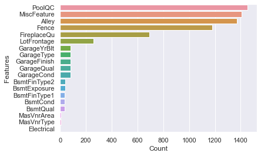

```python
sns.barplot(y = "Features", x = "Count", data = _missing)
```

```python
no_missing_data = data.copy(deep = True)
```

### Handling PoolQC

We will replace NaN with No as data descryption of NA in PoolQC is No Pool

```python
no_missing_data['PoolQC'] = no_missing_data.loc[:, "PoolQC"].fillna("No")
no_missing_data.PoolQC
```

```
0       No
1       No
2       No
3       No
4       No
        ..
1455    No
1456    No
1457    No
1458    No
1459    No
Name: PoolQC, Length: 1460, dtype: object
```

### Handling MiscFeature

We will replace NaN with None as data descryption of NA in MiscFeature is No features covered

```python
no_missing_data['MiscFeature'] = no_missing_data.loc[:, "MiscFeature"].fillna("None")
no_missing_data.MiscFeature
```

```
0       None
1       None
2       None
3       None
4       None
        ...
1455    None
1456    None
1457    Shed
1458    None
1459    None
Name: MiscFeature, Length: 1460, dtype: object
```

### Handling Alley

We will replace NaN with None as data descryption of NA in Alley is No alley access

```python
no_missing_data['Alley'] = no_missing_data.loc[:, "Alley"].fillna("None")
no_missing_data.Alley
```

```
0       None
1       None
2       None
3       None
4       None
        ...
1455    None
1456    None
1457    None
1458    None
1459    None
Name: Alley, Length: 1460, dtype: object
```

### Handling Fence

We will replace NaN with No as data descryption of NA in Fence is No fence

```python
no_missing_data['Fence'] = no_missing_data.loc[:, "Fence"].fillna("No")
no_missing_data.Fence
```

```
0          No
1          No
2          No
3          No
4          No
        ...
1455       No
1456    MnPrv
1457    GdPrv
1458       No
1459       No
Name: Fence, Length: 1460, dtype: object
```

### Handling FireplaceQu

We will replace NaN with No as data descryption of NA in FireplaceQu is No fire place

```python
no_missing_data['FireplaceQu'] = no_missing_data.loc[:, "FireplaceQu"].fillna("No")
no_missing_data.FireplaceQu
```

```
0       No
1       TA
2       TA
3       Gd
4       TA
        ..
1455    TA
1456    TA
1457    Gd
1458    No
1459    No
Name: FireplaceQu, Length: 1460, dtype: object
```

### Handling LotFrontage

```python
no_missing_data['LotFrontage'] = no_missing_data.loc[:, "LotFrontage"].fillna(0)
no_missing_data.LotFrontage
```

```
0       65.0
1       80.0
2       68.0
3       60.0
4       84.0
        ...
1455    62.0
1456    85.0
1457    66.0
1458    68.0
1459    75.0
Name: LotFrontage, Length: 1460, dtype: float64
```

### Handling GarageType

We will replace NaN with No as data descryption of NA in GarageType is No garage

```python
no_missing_data['GarageType'] = no_missing_data.loc[:, "GarageType"].fillna("No")
no_missing_data.GarageType
```

```
0       Attchd
1       Attchd
2       Attchd
3       Detchd
4       Attchd
         ...
1455    Attchd
1456    Attchd
1457    Attchd
1458    Attchd
1459    Attchd
Name: GarageType, Length: 1460, dtype: object
```

### Handling GarageFinish

We will replace NaN with No as data descryption of NA in GarageFinish is No Garage

```python
no_missing_data['GarageFinish'] = no_missing_data.loc[:, "GarageFinish"].fillna("No")
no_missing_data.GarageFinish
```

```
0       RFn
1       RFn
2       RFn
3       Unf
4       RFn
       ...
1455    RFn
1456    Unf
1457    RFn
1458    Unf
1459    Fin
Name: GarageFinish, Length: 1460, dtype: object
```

### Handling GarageQual

We will replace NaN with No as data descryption of NA in GarageQual is No garage

```python
no_missing_data['GarageQual'] = no_missing_data.loc[:, "GarageQual"].fillna("No")
no_missing_data.GarageQual
```

```
0       TA
1       TA
2       TA
3       TA
4       TA
        ..
1455    TA
1456    TA
1457    TA
1458    TA
1459    TA
Name: GarageQual, Length: 1460, dtype: object
```

### Handling GarageCond

We will replace NaN with No as data descryption of NA in GarageCond is No garage

```python
no_missing_data['GarageCond'] = no_missing_data.loc[:, "GarageCond"].fillna("No")
no_missing_data.GarageCond
```

```
0       TA
1       TA
2       TA
3       TA
4       TA
        ..
1455    TA
1456    TA
1457    TA
1458    TA
1459    TA
Name: GarageCond, Length: 1460, dtype: object
```

### Handling BsmtExposure

We will replace NaN with None as data descryption of NA in BsmtExposure is No basement

```python
no_missing_data['BsmtExposure'] = no_missing_data.loc[:, "BsmtExposure"].fillna("None")
no_missing_data.BsmtExposure
```

```
0       No
1       Gd
2       Mn
3       No
4       Av
        ..
1455    No
1456    No
1457    No
1458    Mn
1459    No
Name: BsmtExposure, Length: 1460, dtype: object
```

### Handling BsmtFinType2

We will replace NaN with No as data descryption of NA in BsmtFinType2 is No basement

```python
no_missing_data['BsmtFinType2'] = no_missing_data.loc[:, "BsmtFinType2"].fillna("No")
no_missing_data.BsmtFinType2
```

```
0       Unf
1       Unf
2       Unf
3       Unf
4       Unf
       ...
1455    Unf
1456    Rec
1457    Unf
1458    Rec
1459    LwQ
Name: BsmtFinType2, Length: 1460, dtype: object
```

### Handling BsmtFinType1

We will replace NaN with No as data descryption of NA in BsmtFinType1 is No basement

```python
no_missing_data['BsmtFinType1'] = no_missing_data.loc[:, "BsmtFinType1"].fillna("No")
no_missing_data.BsmtFinType1
```

```
0       GLQ
1       ALQ
2       GLQ
3       ALQ
4       GLQ
       ...
1455    Unf
1456    ALQ
1457    GLQ
1458    GLQ
1459    BLQ
Name: BsmtFinType1, Length: 1460, dtype: object
```

### Handling BsmtCond

We will replace NaN with No as data descryption of NA in BsmtCond is No basement

```python
no_missing_data['BsmtCond'] = no_missing_data.loc[:, "BsmtCond"].fillna("No")
no_missing_data.BsmtCond
```

```
0       TA
1       TA
2       TA
3       Gd
4       TA
        ..
1455    TA
1456    TA
1457    Gd
1458    TA
1459    TA
Name: BsmtCond, Length: 1460, dtype: object
```

### Handling BsmtQual

We will replace NaN with No as data descryption of NA in BsmtQual is No basement

```python
no_missing_data['BsmtQual'] = no_missing_data.loc[:, "BsmtQual"].fillna("No")
no_missing_data.BsmtQual
```

```
0       Gd
1       Gd
2       Gd
3       TA
4       Gd
        ..
1455    Gd
1456    Gd
1457    TA
1458    TA
1459    TA
Name: BsmtQual, Length: 1460, dtype: object
```

### Handling MasVnrArea and MasVnrType

```python
# For MasVnrType replace null with None
no_missing_data['MasVnrType'] = no_missing_data.loc[:, "MasVnrType"].fillna("None")

# For MasVnrArea replace null with 0
no_missing_data['MasVnrArea'] = no_missing_data.loc[:, "MasVnrArea"].fillna(0)
```

### Handling GarageYrBlt

To handle GarageYrBlt we need to explore GarageType, GarageFinish, GarageQual, GarageCond

**Note - We need to check index where GarageYrBlt is None and it should match with index where other features like GarageType, GarageFinish, GarageQual, GarageCond are None**

```python
print(set(no_missing_data.GarageType.values))
print(set(no_missing_data.GarageFinish.values))
print(set(no_missing_data.GarageQual.values))
print(set(no_missing_data.GarageCond.values))
```

```
{'BuiltIn', 'Detchd', 'Basment', '2Types', 'CarPort', 'No', 'Attchd'}
{'No', 'Unf', 'RFn', 'Fin'}
{'Fa', 'Ex', 'TA', 'No', 'Po', 'Gd'}
{'Fa', 'Ex', 'TA', 'No', 'Po', 'Gd'}
```

```python
# We will get index where GarageType, GarageFinish, GarageQual, GarageCond having values as no garage.
a = no_missing_data.loc[(no_missing_data.GarageType == "No")
                        & (no_missing_data.GarageFinish == "No")
                        & (no_missing_data.GarageQual == "No")
                        & (no_missing_data.GarageCond == "No")].index.values
a
```

```
array([  39,   48,   78,   88,   89,   99,  108,  125,  127,  140,  148,
        155,  163,  165,  198,  210,  241,  250,  287,  291,  307,  375,
        386,  393,  431,  434,  441,  464,  495,  520,  528,  533,  535,
        562,  582,  613,  614,  620,  635,  636,  638,  649,  705,  710,
        738,  750,  784,  826,  843,  921,  942,  954,  960,  968,  970,
        976, 1009, 1011, 1030, 1038, 1096, 1123, 1131, 1137, 1143, 1173,
       1179, 1218, 1219, 1234, 1257, 1283, 1323, 1325, 1326, 1337, 1349,
       1407, 1449, 1450, 1453])
```

```python
# Getting index where GarageYrBlt is None
b = no_missing_data[no_missing_data['GarageYrBlt'].isnull()].index.values
b
```

```
array([  39,   48,   78,   88,   89,   99,  108,  125,  127,  140,  148,
        155,  163,  165,  198,  210,  241,  250,  287,  291,  307,  375,
        386,  393,  431,  434,  441,  464,  495,  520,  528,  533,  535,
        562,  582,  613,  614,  620,  635,  636,  638,  649,  705,  710,
        738,  750,  784,  826,  843,  921,  942,  954,  960,  968,  970,
        976, 1009, 1011, 1030, 1038, 1096, 1123, 1131, 1137, 1143, 1173,
       1179, 1218, 1219, 1234, 1257, 1283, 1323, 1325, 1326, 1337, 1349,
       1407, 1449, 1450, 1453])
```

```python
a == b
```

```
array([ True,  True,  True,  True,  True,  True,  True,  True,  True,
        True,  True,  True,  True,  True,  True,  True,  True,  True,
        True,  True,  True,  True,  True,  True,  True,  True,  True,
        True,  True,  True,  True,  True,  True,  True,  True,  True,
        True,  True,  True,  True,  True,  True,  True,  True,  True,
        True,  True,  True,  True,  True,  True,  True,  True,  True,
        True,  True,  True,  True,  True,  True,  True,  True,  True,
        True,  True,  True,  True,  True,  True,  True,  True,  True,
        True,  True,  True,  True,  True,  True,  True,  True,  True])
```

Since both index are same we can drop all GarageYrBlt feature

```python
no_missing_data.drop(['GarageYrBlt'], axis = 1, inplace = True)
```

### Handling Electrical

Since there is only one missing value we can drop the tuple

```python
# Check for missing values
m = no_missing_data.isnull().sum()
m[m > 0]
```

```
Electrical    1
dtype: int64
```

```python
# We will drop all missing values
data_cleaned = no_missing_data.dropna()
```

```python
# Check for final missing values
m = data_cleaned.isnull().sum()
m[m > 0]
```

```
Series([], dtype: int64)
```

There are no missing values present in the data.

```python
print("Shape of original dataset - ", data.shape)
print("Shape of dataset after handling missing values - ", data_cleaned.shape)
print(f"Percentage of data dropped - {(data.shape[0] - data_cleaned.shape[0]) / data.shape[0] * 100}%")
```

```
Shape of original dataset -  (1460, 81)
Shape of dataset after handling missing values -  (1459, 80)
Percentage of data dropped - 0.0684931506849315%
```

```python
# Drop Id feature as it is redundant
data_cleaned = data_cleaned.drop(['Id'], axis = 1).reset_index(drop = True)
```

```python
data_cleaned.head()
```

|  | MSSubClass | MSZoning | LotFrontage | LotArea | Street | Alley | LotShape | LandContour | Utilities | LotConfig | ... | PoolArea | PoolQC | Fence | MiscFeature | MiscVal | MoSold | YrSold | SaleType | SaleCondition | SalePrice |
| --- | --- | --- | --- | --- | --- | --- | --- | --- | --- | --- | --- | --- | --- | --- | --- | --- | --- | --- | --- | --- | --- |
| 0 | 60 | RL | 65.0 | 8450 | Pave | None | Reg | Lvl | AllPub | Inside | ... | 0 | No | No | None | 0 | 2 | 2008 | WD | Normal | 208500 |
| 1 | 20 | RL | 80.0 | 9600 | Pave | None | Reg | Lvl | AllPub | FR2 | ... | 0 | No | No | None | 0 | 5 | 2007 | WD | Normal | 181500 |
| 2 | 60 | RL | 68.0 | 11250 | Pave | None | IR1 | Lvl | AllPub | Inside | ... | 0 | No | No | None | 0 | 9 | 2008 | WD | Normal | 223500 |
| 3 | 70 | RL | 60.0 | 9550 | Pave | None | IR1 | Lvl | AllPub | Corner | ... | 0 | No | No | None | 0 | 2 | 2006 | WD | Abnorml | 140000 |
| 4 | 60 | RL | 84.0 | 14260 | Pave | None | IR1 | Lvl | AllPub | FR2 | ... | 0 | No | No | None | 0 | 12 | 2008 | WD | Normal | 250000 |

5 rows × 79 columns

## 3.3. Statistical Summary

Here we take a look at the summary of each attribute. This includes the count, mean, the min and max values as well as some percentiles for numeric variables. **Go to table of contents**

**For numerical variables, we use .describe(). For categorical variables we use describe(include='object').**

```python
# data frame with numerical features
data_cleaned.describe()
```

|  | MSSubClass | LotFrontage | LotArea | OverallQual | OverallCond | YearBuilt | YearRemodAdd | MasVnrArea | BsmtFinSF1 | BsmtFinSF2 | ... | WoodDeckSF | OpenPorchSF | EnclosedPorch | 3SsnPorch | ScreenPorch | PoolArea | MiscVal | MoSold | YrSold | SalePrice |
| --- | --- | --- | --- | --- | --- | --- | --- | --- | --- | --- | --- | --- | --- | --- | --- | --- | --- | --- | --- | --- | --- |
| count | 1459.000000 | 1459.000000 | 1459.000000 | 1459.000000 | 1459.000000 | 1459.000000 | 1459.000000 | 1459.000000 | 1459.000000 | 1459.000000 | ... | 1459.000000 | 1459.000000 | 1459.000000 | 1459.000000 | 1459.000000 | 1459.000000 | 1459.000000 | 1459.000000 | 1459.000000 | 1459.000000 |
| mean | 56.881426 | 57.612748 | 10517.363948 | 6.100069 | 5.575737 | 1971.244003 | 1984.850583 | 103.187800 | 443.943797 | 46.581220 | ... | 94.240576 | 46.692255 | 21.969157 | 3.411926 | 15.071282 | 2.760795 | 43.518849 | 6.322824 | 2007.815627 | 180930.394791 |
| std | 42.310746 | 34.673850 | 9984.666267 | 1.383171 | 1.113079 | 30.199555 | 20.644343 | 180.773158 | 456.106417 | 161.369977 | ... | 125.381679 | 66.267472 | 61.137400 | 29.327247 | 55.775138 | 40.191018 | 496.291826 | 2.704331 | 1.328542 | 79468.964025 |
| min | 20.000000 | 0.000000 | 1300.000000 | 1.000000 | 1.000000 | 1872.000000 | 1950.000000 | 0.000000 | 0.000000 | 0.000000 | ... | 0.000000 | 0.000000 | 0.000000 | 0.000000 | 0.000000 | 0.000000 | 0.000000 | 1.000000 | 2006.000000 | 34900.000000 |
| 25% | 20.000000 | 42.000000 | 7549.000000 | 5.000000 | 5.000000 | 1954.000000 | 1967.000000 | 0.000000 | 0.000000 | 0.000000 | ... | 0.000000 | 0.000000 | 0.000000 | 0.000000 | 0.000000 | 0.000000 | 0.000000 | 5.000000 | 2007.000000 | 129950.000000 |
| 50% | 50.000000 | 63.000000 | 9477.000000 | 6.000000 | 5.000000 | 1973.000000 | 1994.000000 | 0.000000 | 384.000000 | 0.000000 | ... | 0.000000 | 25.000000 | 0.000000 | 0.000000 | 0.000000 | 0.000000 | 0.000000 | 6.000000 | 2008.000000 | 163000.000000 |
| 75% | 70.000000 | 79.000000 | 11603.000000 | 7.000000 | 6.000000 | 2000.000000 | 2004.000000 | 164.500000 | 712.500000 | 0.000000 | ... | 168.000000 | 68.000000 | 0.000000 | 0.000000 | 0.000000 | 0.000000 | 0.000000 | 8.000000 | 2009.000000 | 214000.000000 |
| max | 190.000000 | 313.000000 | 215245.000000 | 10.000000 | 9.000000 | 2010.000000 | 2010.000000 | 1600.000000 | 5644.000000 | 1474.000000 | ... | 857.000000 | 547.000000 | 552.000000 | 508.000000 | 480.000000 | 738.000000 | 15500.000000 | 12.000000 | 2010.000000 | 755000.000000 |

8 rows × 36 columns

The above output illustrates the summary statistics of all the numeric variables like the mean, median(50%), minimum, and maximum values, along with the standard deviation

```python
# data frame with categorical features
data.describe(include='object')
```

|  | MSZoning | Street | Alley | LotShape | LandContour | Utilities | LotConfig | LandSlope | Neighborhood | Condition1 | ... | GarageType | GarageFinish | GarageQual | GarageCond | PavedDrive | PoolQC | Fence | MiscFeature | SaleType | SaleCondition |
| --- | --- | --- | --- | --- | --- | --- | --- | --- | --- | --- | --- | --- | --- | --- | --- | --- | --- | --- | --- | --- | --- |
| count | 1460 | 1460 | 91 | 1460 | 1460 | 1460 | 1460 | 1460 | 1460 | 1460 | ... | 1379 | 1379 | 1379 | 1379 | 1460 | 7 | 281 | 54 | 1460 | 1460 |
| unique | 5 | 2 | 2 | 4 | 4 | 2 | 5 | 3 | 25 | 9 | ... | 6 | 3 | 5 | 5 | 3 | 3 | 4 | 4 | 9 | 6 |
| top | RL | Pave | Grvl | Reg | Lvl | AllPub | Inside | Gtl | NAmes | Norm | ... | Attchd | Unf | TA | TA | Y | Gd | MnPrv | Shed | WD | Normal |
| freq | 1151 | 1454 | 50 | 925 | 1311 | 1459 | 1052 | 1382 | 225 | 1260 | ... | 870 | 605 | 1311 | 1326 | 1340 | 3 | 157 | 49 | 1267 | 1198 |

4 rows × 43 columns

## 4. Exploratiory Data Analysis(EDA)

Explore the features(independent variables) and check if they are inter-related to each other. **Go to table of contents**  
This is acheived using following steps:

1. Univariate Analysis
2. Multivariate Analysis

## 4.1. Univariate Analysis

**Exploring individual features**

### Analysis of Sales Price

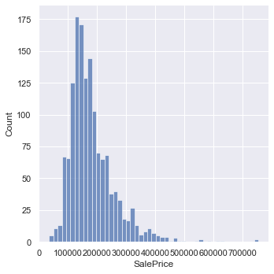

```python
sns.displot(data_cleaned.SalePrice)
```

### Analysis of Numerical features

```python
# Get numeric features
numeric_features = [i for i in data_cleaned.columns.values if data_cleaned[i].dtype != "object"]
numeric_features
```

```
['MSSubClass',
 'LotFrontage',
 'LotArea',
 'OverallQual',
 'OverallCond',
 'YearBuilt',
 'YearRemodAdd',
 'MasVnrArea',
 'BsmtFinSF1',
 'BsmtFinSF2',
 'BsmtUnfSF',
 'TotalBsmtSF',
 '1stFlrSF',
 '2ndFlrSF',
 'LowQualFinSF',
 'GrLivArea',
 'BsmtFullBath',
 'BsmtHalfBath',
 'FullBath',
 'HalfBath',
 'BedroomAbvGr',
 'KitchenAbvGr',
 'TotRmsAbvGrd',
 'Fireplaces',
 'GarageCars',
 'GarageArea',
 'WoodDeckSF',
 'OpenPorchSF',
 'EnclosedPorch',
 '3SsnPorch',
 'ScreenPorch',
 'PoolArea',
 'MiscVal',
 'MoSold',
 'YrSold',
 'SalePrice']
```

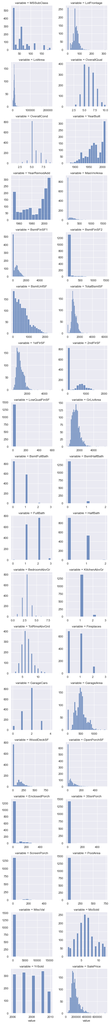

```python
# Plot histplot of all numeric features
f = pd.melt(data_cleaned, value_vars = numeric_features)
g = sns.FacetGrid(f, col="variable",  col_wrap=2, sharex=False, sharey=False)
g = g.map(sns.histplot, "value")
```

### Analysis of Categorical features

```python
# Get list of  features with datatype as object
categorical_features = [i for i in data_cleaned.columns.values if data_cleaned[i].dtype == "object"]
categorical_features
```

```
['MSZoning',
 'Street',
 'Alley',
 'LotShape',
 'LandContour',
 'Utilities',
 'LotConfig',
 'LandSlope',
 'Neighborhood',
 'Condition1',
 'Condition2',
 'BldgType',
 'HouseStyle',
 'RoofStyle',
 'RoofMatl',
 'Exterior1st',
 'Exterior2nd',
 'MasVnrType',
 'ExterQual',
 'ExterCond',
 'Foundation',
 'BsmtQual',
 'BsmtCond',
 'BsmtExposure',
 'BsmtFinType1',
 'BsmtFinType2',
 'Heating',
 'HeatingQC',
 'CentralAir',
 'Electrical',
 'KitchenQual',
 'Functional',
 'FireplaceQu',
 'GarageType',
 'GarageFinish',
 'GarageQual',
 'GarageCond',
 'PavedDrive',
 'PoolQC',
 'Fence',
 'MiscFeature',
 'SaleType',
 'SaleCondition']
```

```python
# Function to plot categorical features with respect to SalePrice
def boxplot(x, y, **kwargs):
    sns.boxplot(x=x, y=y)
    x=plt.xticks(rotation=90)
```

```python
# Function to convert datatype to category
def convert_type(data, features):
    for feature in features:
        data[feature] = data[feature].astype('category')

    return data
```

```python
# Converting object type to categorical
data_cleaned = convert_type(data_cleaned, categorical_features)
data_cleaned.info()
```

```
<class 'pandas.core.frame.DataFrame'>
RangeIndex: 1459 entries, 0 to 1458
Data columns (total 79 columns):
 #   Column         Non-Null Count  Dtype
---  ------         --------------  -----
 0   MSSubClass     1459 non-null   int64
 1   MSZoning       1459 non-null   category
 2   LotFrontage    1459 non-null   float64
 3   LotArea        1459 non-null   int64
 4   Street         1459 non-null   category
 5   Alley          1459 non-null   category
 6   LotShape       1459 non-null   category
 7   LandContour    1459 non-null   category
 8   Utilities      1459 non-null   category
 9   LotConfig      1459 non-null   category
```

[output cut: 71 more lines]

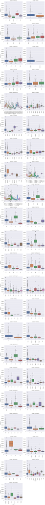

```python
# Visualize categorical features
f = pd.melt(data_cleaned, id_vars=['SalePrice'], value_vars = categorical_features)
g = sns.FacetGrid(f, col="variable",  col_wrap=2, sharex=False, sharey=False, height = 5)
g = g.map(boxplot, "value", "SalePrice")
```

Conclusion of Univariate Analysis -

- There are some columns which hold categorical importance like MSSubClass, MoSold but are represented as numeric features
- Some numeric feature are skewed so to overcome this we need to apply log transformation
- Some categorical features hold numeric importance
- Need to simply categorical features to make them more precise

**Converting numerical to categorical features to do so let's create dictonaries**

```python
mssubclass = {20 : "SC20", 30 : "SC30", 40 : "SC40", 45 : "SC45",
                                       50 : "SC50", 60 : "SC60", 70 : "SC70", 75 : "SC75",
                                       80 : "SC80", 85 : "SC85", 90 : "SC90", 120 : "SC120",
                                       150 : "SC150", 160 : "SC160", 180 : "SC180", 190 : "SC190"}
mssubclass
```

```
{20: 'SC20',
 30: 'SC30',
 40: 'SC40',
 45: 'SC45',
 50: 'SC50',
 60: 'SC60',
 70: 'SC70',
 75: 'SC75',
 80: 'SC80',
 85: 'SC85',
 90: 'SC90',
 120: 'SC120',
 150: 'SC150',
 160: 'SC160',
 180: 'SC180',
 190: 'SC190'}
```

```python
msold = {1 : "Jan", 2 : "Feb", 3 : "Mar", 4 : "Apr", 5 : "May", 6 : "Jun",
                                   7 : "Jul", 8 : "Aug", 9 : "Sep", 10 : "Oct", 11 : "Nov", 12 : "Dec"}
msold
```

```
{1: 'Jan',
 2: 'Feb',
 3: 'Mar',
 4: 'Apr',
 5: 'May',
 6: 'Jun',
 7: 'Jul',
 8: 'Aug',
 9: 'Sep',
 10: 'Oct',
 11: 'Nov',
 12: 'Dec'}
```

```python
# Create a copy
data_preprocessed = data_cleaned.copy(deep = True)

# Convert features to category
data_preprocessed["MSSubClass"] = data_preprocessed.MSSubClass.map(mssubclass)
data_preprocessed["MoSold"] = data_preprocessed.MoSold.map(msold)
data_preprocessed = convert_type(data_preprocessed, ["MSSubClass", "MoSold"])

# Get datatype
data_preprocessed.info()
```

```
<class 'pandas.core.frame.DataFrame'>
RangeIndex: 1459 entries, 0 to 1458
Data columns (total 79 columns):
 #   Column         Non-Null Count  Dtype
---  ------         --------------  -----
 0   MSSubClass     1459 non-null   category
 1   MSZoning       1459 non-null   category
 2   LotFrontage    1459 non-null   float64
 3   LotArea        1459 non-null   int64
 4   Street         1459 non-null   category
 5   Alley          1459 non-null   category
 6   LotShape       1459 non-null   category
 7   LandContour    1459 non-null   category
 8   Utilities      1459 non-null   category
 9   LotConfig      1459 non-null   category
```

[output cut: 71 more lines]

**Encoding categorical features as numerical features**

```python
# Encode some categorical features as ordered numbers when there is information in the order
data_preprocessed = data_preprocessed.replace({"Alley" : {"None": 0, "Grvl" : 1, "Pave" : 2},
                       "CentralAir" : {"N" : 0, "Y" : 1},
                       "BsmtCond" : {"No" : 0, "Po" : 1, "Fa" : 2, "TA" : 3, "Gd" : 4, "Ex" : 5},
                       "BsmtExposure" : {"No" : 0, "None": 0, "Mn" : 1, "Av": 2, "Gd" : 3},
                       "BsmtFinType1" : {"No" : 0, "Unf" : 1, "LwQ": 2, "Rec" : 3, "BLQ" : 4,
                                         "ALQ" : 5, "GLQ" : 6},
                       "BsmtFinType2" : {"No" : 0, "Unf" : 1, "LwQ": 2, "Rec" : 3, "BLQ" : 4,
                                         "ALQ" : 5, "GLQ" : 6},
                       "BsmtQual" : {"No" : 0, "Po" : 1, "Fa" : 2, "TA": 3, "Gd" : 4, "Ex" : 5},
                       "ExterCond" : {"Po" : 1, "Fa" : 2, "TA": 3, "Gd": 4, "Ex" : 5},
                       "ExterQual" : {"Po" : 1, "Fa" : 2, "TA": 3, "Gd": 4, "Ex" : 5},
                       "FireplaceQu" : {"No" : 0, "Po" : 1, "Fa" : 2, "TA" : 3, "Gd" : 4, "Ex" : 5},
                       "Functional" : {"Sal" : 1, "Sev" : 2, "Maj2" : 3, "Maj1" : 4, "Mod": 5,
                                       "Min2" : 6, "Min1" : 7, "Typ" : 8},
                       "GarageCond" : {"No" : 0, "Po" : 1, "Fa" : 2, "TA" : 3, "Gd" : 4, "Ex" : 5},
                       "GarageQual" : {"No" : 0, "Po" : 1, "Fa" : 2, "TA" : 3, "Gd" : 4, "Ex" : 5},
                       "GarageFinish" : {'Fin' : 3, 'RFn' : 2, 'Unf' : 1, 'No' : 0},
                       "HeatingQC" : {"Po" : 1, "Fa" : 2, "TA" : 3, "Gd" : 4, "Ex" : 5},
                       "KitchenQual" : {"Po" : 1, "Fa" : 2, "TA" : 3, "Gd" : 4, "Ex" : 5},
                       "LandSlope" : {"Sev" : 1, "Mod" : 2, "Gtl" : 3},
                       "LotShape" : {"IR3" : 1, "IR2" : 2, "IR1" : 3, "Reg" : 4},
                       "PavedDrive" : {"N" : 0, "P" : 1, "Y" : 2},
                       "PoolQC" : {"No" : 0, "Fa" : 1, "TA" : 2, "Gd" : 3, "Ex" : 4},
                       "Street" : {"Grvl" : 1, "Pave" : 2},
                       "Fence" : {'GdPrv' : 4, 'GdWo' : 2, 'MnPrv' : 3, 'MnWw' : 1, 'No' : 0},
                       "SaleCondition" : {"Abnorml" : 0, "Alloca" : 0, "AdjLand" : 0, "Family" : 0, "Normal" : 0, "Partial" : 1},
                       "MasVnrType" : {'BrkCmn' : 1, 'BrkFace' : 1, 'None' : 0, 'Stone' : 1, "CBlock" : 1},
                       "Utilities" : {"ELO" : 1, "NoSeWa" : 2, "NoSewr" : 3, "AllPub" : 4}}
                     )
```

```python
# Get dataset info
data_preprocessed.info()
```

```
<class 'pandas.core.frame.DataFrame'>
RangeIndex: 1459 entries, 0 to 1458
Data columns (total 79 columns):
 #   Column         Non-Null Count  Dtype
---  ------         --------------  -----
 0   MSSubClass     1459 non-null   category
 1   MSZoning       1459 non-null   category
 2   LotFrontage    1459 non-null   float64
 3   LotArea        1459 non-null   int64
 4   Street         1459 non-null   int64
 5   Alley          1459 non-null   int64
 6   LotShape       1459 non-null   int64
 7   LandContour    1459 non-null   category
 8   Utilities      1459 non-null   int64
 9   LotConfig      1459 non-null   category
```

[output cut: 71 more lines]

**We will create modify exisiting features to make them more precise**

```python
data_preprocessed["OverallQual"] = data_preprocessed.OverallQual.replace({1 : 1, 2 : 1, 3 : 1, # bad
                                                       4 : 2, 5 : 2, 6 : 2, # average
                                                       7 : 3, 8 : 3, 9 : 3, 10 : 3 # good
                                                      })
data_preprocessed["OverallCond"] = data_preprocessed.OverallCond.replace({1 : 1, 2 : 1, 3 : 1, # bad
                                                       4 : 2, 5 : 2, 6 : 2, # average
                                                       7 : 3, 8 : 3, 9 : 3, 10 : 3 # good
                                                      })
data_preprocessed["PoolQC"] = data_preprocessed.PoolQC.replace({1 : 1, 2 : 1, # average
                                             3 : 2, 4 : 2 # good
                                            })
data_preprocessed["GarageCond"] = data_preprocessed.GarageCond.replace({1 : 1, # bad
                                                     2 : 1, 3 : 1, # average
                                                     4 : 2, 5 : 2 # good
                                                    })
data_preprocessed["GarageQual"] = data_preprocessed.GarageQual.replace({1 : 1, # bad
                                                     2 : 1, 3 : 1, # average
                                                     4 : 2, 5 : 2 # good
                                                    })
data_preprocessed["FireplaceQu"] = data_preprocessed.FireplaceQu.replace({1 : 1, # bad
                                                       2 : 1, 3 : 1, # average
                                                       4 : 2, 5 : 2 # good
                                                      })
data_preprocessed["Functional"] = data_preprocessed.Functional.replace({1 : 1, 2 : 1, # bad
                                                     3 : 2, 4 : 2, # major
                                                     5 : 3, 6 : 3, 7 : 3, # minor
                                                     8 : 4 # typical
                                                    })
data_preprocessed["KitchenQual"] = data_preprocessed.KitchenQual.replace({1 : 0, # bad
                                                       2 : 1, 3 : 1, # average
                                                       4 : 2, 5 : 2 # good
                                                      })
data_preprocessed["HeatingQC"] = data_preprocessed.HeatingQC.replace({1 : 0, # bad
                                                   2 : 1, 3 : 1, # average
                                                   4 : 2, 5 : 2 # good
                                                  })
data_preprocessed["BsmtFinType1"] = data_preprocessed.BsmtFinType1.replace({1 : 1, # unfinished
                                                         2 : 1, 3 : 1, # rec room
                                                         4 : 2, 5 : 2, 6 : 2 # living quarters
                                                        })
data_preprocessed["BsmtFinType2"] = data_preprocessed.BsmtFinType2.replace({1 : 1, # unfinished
                                                         2 : 1, 3 : 1, # rec room
                                                         4 : 2, 5 : 2, 6 : 2 # living quarters
                                                        })
data_preprocessed["BsmtCond"] = data_preprocessed.BsmtCond.replace({1 : 1, # bad
                                                 2 : 1, 3 : 1, # average
                                                 4 : 2, 5 : 2 # good
                                                })
data_preprocessed["BsmtQual"] = data_preprocessed.BsmtQual.replace({1 : 1, # bad
                                                 2 : 1, 3 : 1, # average
                                                 4 : 2, 5 : 2 # good
                                                })
data_preprocessed["ExterCond"] = data_preprocessed.ExterCond.replace({1 : 0, # bad
                                                   2 : 1, 3 : 1, # average
                                                   4 : 2, 5 : 2 # good
                                                  })
data_preprocessed["ExterQual"] = data_preprocessed.ExterQual.replace({1 : 0, # bad
                                                   2 : 1, 3 : 1, # average
                                                   4 : 2, 5 : 2 # good
                                                  })
```

```python
data_preprocessed.info()
```

```
<class 'pandas.core.frame.DataFrame'>
RangeIndex: 1459 entries, 0 to 1458
Data columns (total 79 columns):
 #   Column         Non-Null Count  Dtype
---  ------         --------------  -----
 0   MSSubClass     1459 non-null   category
 1   MSZoning       1459 non-null   category
 2   LotFrontage    1459 non-null   float64
 3   LotArea        1459 non-null   int64
 4   Street         1459 non-null   int64
 5   Alley          1459 non-null   int64
 6   LotShape       1459 non-null   int64
 7   LandContour    1459 non-null   category
 8   Utilities      1459 non-null   int64
 9   LotConfig      1459 non-null   category
```

[output cut: 71 more lines]

## 4.2. Multivariate Analysis

Before multivariate analysis we will divide dataset to muerical data and categorical data so that we can analyse them in depth

```python
# Extracting numerical features list
numerical_features = data_preprocessed.select_dtypes(include = ["int64", "float64"]).columns

# Extracting categorical features list
categorical_features = data_preprocessed.select_dtypes(exclude = ["int64", "float64"]).columns
```

```python
# Numerical dataset
numeric_data = data_preprocessed[numerical_features]

# Categorical dataset
cat_data = data_preprocessed[categorical_features]

# Dependent variable as pandas series
y = numeric_data["SalePrice"]

# Remove dependent variable from numerical dataset
numeric_data = numeric_data.drop('SalePrice', axis = 1)
numerical_features = numeric_data.columns.values
```

## Correlation

We will use spearman correlation to identify relationship between numeric features and dependent variable

```python
# Function to return spearman coeffient for numerical features
def correlation_spearman(data, features, saleprice):
    correlations = pd.DataFrame()
    correlations["features"] = features

    # Calculating spearman correlation
    correlations["Correlation"] = [data[i].corr(saleprice, 'spearman') for i in features]

    # Sort with respective to correlation
    correlations.sort_values('Correlation', inplace = True)
    correlations.reset_index(drop = True, inplace = True)

    return correlations
```

```python
# Get correlation of nuemric features
correlations = correlation_spearman(numeric_data, numerical_features, y)
correlations.head()
```

|  | features | Correlation |
| --- | --- | --- |
| 0 | LotShape | -0.321146 |
| 1 | EnclosedPorch | -0.218367 |
| 2 | Fence | -0.186096 |
| 3 | KitchenAbvGr | -0.164797 |
| 4 | Alley | -0.122267 |

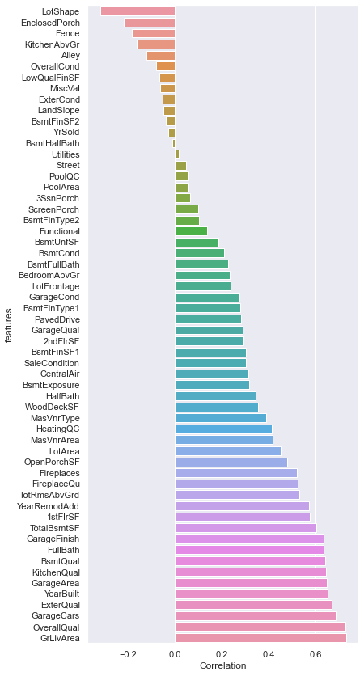

```python
# Visualizing correlation as barplot
plt.figure(figsize=(6, 0.25*len(numerical_features)))
sns.barplot(data = correlations, y='features', x='Correlation', orient='h')
```

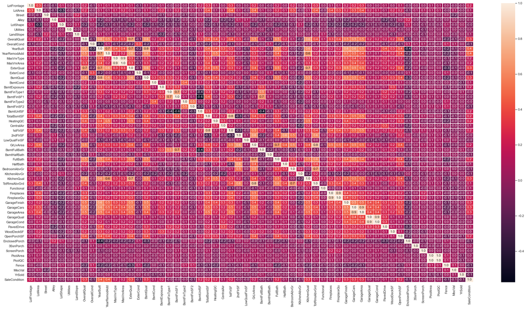

```python
#correlation heat map
f,ax = plt.subplots(figsize=(35, 18))
sns.heatmap(numeric_data.corr(method = 'spearman'), annot=True, linewidths=.5, fmt= '.1f',ax=ax)
```

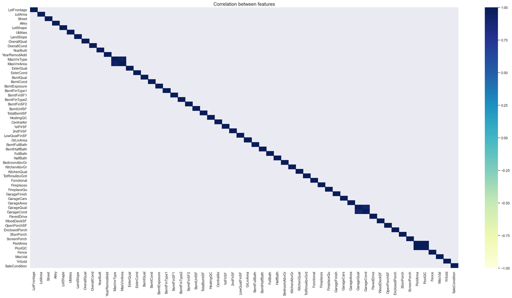

```python
corr = numeric_data.corr(method = 'spearman')
plt.figure(figsize=(30, 15))
sns.heatmap(corr[(corr >= 0.9) | (corr <= -0.9)],
            cmap='YlGnBu', vmax=1.0, vmin=-1.0,
            annot=True, annot_kws={"size": 1})
plt.title('Correlation between features', fontsize=15)
plt.show()
```

We will get list of numeric features with skewness greater than 0.5 so that we can perform logarithm tranformation

```python
from scipy.stats import skew

# Get skewness of all nuemric features
skewness = numeric_data.apply(lambda x: skew(x))

# Getfeatures with skewness greater than 0.5
skewness = skewness[abs(skewness) > 0.5]

print(str(skewness.shape[0]) + " skewed numerical features to log transform")

print("Skewed features - ")
skewed_features = list(skewness.index)
print(skewed_features)
```

[output not shown]

```python
# Applying log transformation for skewed features
numeric_data = numeric_data.copy()
numeric_data.loc[:,skewed_features] = np.log1p(data_preprocessed[skewed_features])
```

```python
numeric_data.head()
```

|  | LotFrontage | LotArea | Street | Alley | LotShape | Utilities | LandSlope | OverallQual | OverallCond | YearBuilt | ... | OpenPorchSF | EnclosedPorch | 3SsnPorch | ScreenPorch | PoolArea | PoolQC | Fence | MiscVal | YrSold | SaleCondition |
| --- | --- | --- | --- | --- | --- | --- | --- | --- | --- | --- | --- | --- | --- | --- | --- | --- | --- | --- | --- | --- | --- |
| 0 | 65.0 | 9.042040 | 1.098612 | 0.0 | 1.609438 | 1.609438 | 1.386294 | 3 | 1.098612 | 7.602900 | ... | 4.127134 | 0.000000 | 0.0 | 0.0 | 0.0 | 0.0 | 0.0 | 0.0 | 2008 | 0.0 |
| 1 | 80.0 | 9.169623 | 1.098612 | 0.0 | 1.609438 | 1.609438 | 1.386294 | 2 | 1.386294 | 7.589336 | ... | 0.000000 | 0.000000 | 0.0 | 0.0 | 0.0 | 0.0 | 0.0 | 0.0 | 2007 | 0.0 |
| 2 | 68.0 | 9.328212 | 1.098612 | 0.0 | 1.386294 | 1.609438 | 1.386294 | 3 | 1.098612 | 7.601902 | ... | 3.761200 | 0.000000 | 0.0 | 0.0 | 0.0 | 0.0 | 0.0 | 0.0 | 2008 | 0.0 |
| 3 | 60.0 | 9.164401 | 1.098612 | 0.0 | 1.386294 | 1.609438 | 1.386294 | 3 | 1.098612 | 7.557995 | ... | 3.583519 | 5.609472 | 0.0 | 0.0 | 0.0 | 0.0 | 0.0 | 0.0 | 2006 | 0.0 |
| 4 | 84.0 | 9.565284 | 1.098612 | 0.0 | 1.386294 | 1.609438 | 1.386294 | 3 | 1.098612 | 7.601402 | ... | 4.442651 | 0.000000 | 0.0 | 0.0 | 0.0 | 0.0 | 0.0 | 0.0 | 2008 | 0.0 |

5 rows × 58 columns

```python
numerical_features = numeric_data.columns
```

## ANOVA test

We will perform one way anova to identify categorical features having higher impact on SalePrice

```python
from scipy.stats import f_oneway
def anova_test(data, categorical_features, y):
    data = pd.concat([data, y], axis = 1)
    anova = pd.DataFrame()
    anova['features']  = categorical_features
    pvalues = list()
    for category in categorical_features:
        samples = []
        for cls in data[category].unique():
            s = data[data[category] == cls]['SalePrice'].values
            samples.append(s)
        pvalue = f_oneway(*samples)[1]
        pvalues.append(pvalue)

    anova['pvalues'] = pvalues
    anova.sort_values('pvalues', inplace = True)
    anova.reset_index(drop  = True, inplace = True)
    return anova
```

```python
anova = anova_test(cat_data, categorical_features, y)
anova.head()
```

|  | features | pvalues |
| --- | --- | --- |
| 0 | Neighborhood | 8.807309e-226 |
| 1 | Foundation | 4.785251e-91 |
| 2 | GarageType | 3.204858e-87 |
| 3 | MSSubClass | 1.006939e-78 |
| 4 | Exterior1st | 2.347229e-43 |

```python
anova['disparity'] = np.log(1./anova['pvalues'].values)
anova
```

|  | features | pvalues | disparity |
| --- | --- | --- | --- |
| 0 | Neighborhood | 8.807309e-226 | 518.208649 |
| 1 | Foundation | 4.785251e-91 | 207.969705 |
| 2 | GarageType | 3.204858e-87 | 199.160235 |
| 3 | MSSubClass | 1.006939e-78 | 179.594722 |
| 4 | Exterior1st | 2.347229e-43 | 98.157924 |
| 5 | Exterior2nd | 4.373194e-43 | 97.535665 |
| 6 | SaleType | 5.473290e-42 | 95.008694 |
| 7 | MSZoning | 9.013044e-35 | 78.391805 |
| 8 | HouseStyle | 3.575128e-25 | 56.290626 |
| 9 | Electrical | 1.663249e-18 | 40.937759 |
| 10 | RoofStyle | 3.807093e-17 | 37.807081 |
| 11 | BldgType | 2.065650e-10 | 22.300406 |
| 12 | LandContour | 2.780585e-08 | 17.398019 |
| 13 | RoofMatl | 7.348101e-08 | 16.426239 |
| 14 | Condition1 | 8.961459e-08 | 16.227748 |
| 15 | LotConfig | 3.216094e-06 | 12.647343 |
| 16 | Heating | 7.564952e-04 | 7.186814 |
| 17 | MiscFeature | 3.503139e-02 | 3.351511 |
| 18 | Condition2 | 4.355704e-02 | 3.133684 |
| 19 | MoSold | 4.861395e-01 | 0.721260 |

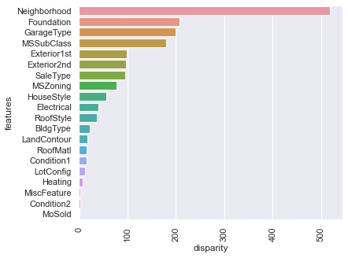

```python
plt.figure(figsize=(6, 0.25 * len(categorical_features)))
sns.barplot(data = anova, y = 'features', x = 'disparity', orient = 'h')
x = plt.xticks(rotation = 90)
```

Perform Logarithmic tranformation on SalePrice to reduce skewness

```python
y = np.log(y)
y
```

```
0       12.247694
1       12.109011
2       12.317167
3       11.849398
4       12.429216
          ...
1454    12.072541
1455    12.254863
1456    12.493130
1457    11.864462
1458    11.901583
Name: SalePrice, Length: 1459, dtype: float64
```

## 5. Encoding categorical Features

Creating dummies for categorical data. **Go to table of contents**

```python
cat_data = pd.get_dummies(cat_data)
cat_data.head()
```

|  | MSSubClass_SC120 | MSSubClass_SC160 | MSSubClass_SC180 | MSSubClass_SC190 | MSSubClass_SC20 | MSSubClass_SC30 | MSSubClass_SC40 | MSSubClass_SC45 | MSSubClass_SC50 | MSSubClass_SC60 | ... | MoSold_Sep | SaleType_COD | SaleType_CWD | SaleType_Con | SaleType_ConLD | SaleType_ConLI | SaleType_ConLw | SaleType_New | SaleType_Oth | SaleType_WD |
| --- | --- | --- | --- | --- | --- | --- | --- | --- | --- | --- | --- | --- | --- | --- | --- | --- | --- | --- | --- | --- | --- |
| 0 | 0 | 0 | 0 | 0 | 0 | 0 | 0 | 0 | 0 | 1 | ... | 0 | 0 | 0 | 0 | 0 | 0 | 0 | 0 | 0 | 1 |
| 1 | 0 | 0 | 0 | 0 | 1 | 0 | 0 | 0 | 0 | 0 | ... | 0 | 0 | 0 | 0 | 0 | 0 | 0 | 0 | 0 | 1 |
| 2 | 0 | 0 | 0 | 0 | 0 | 0 | 0 | 0 | 0 | 1 | ... | 1 | 0 | 0 | 0 | 0 | 0 | 0 | 0 | 0 | 1 |
| 3 | 0 | 0 | 0 | 0 | 0 | 0 | 0 | 0 | 0 | 0 | ... | 0 | 0 | 0 | 0 | 0 | 0 | 0 | 0 | 0 | 1 |
| 4 | 0 | 0 | 0 | 0 | 0 | 0 | 0 | 0 | 0 | 1 | ... | 0 | 0 | 0 | 0 | 0 | 0 | 0 | 0 | 0 | 1 |

5 rows × 179 columns

```python
cat_data
```

|  | MSSubClass_SC120 | MSSubClass_SC160 | MSSubClass_SC180 | MSSubClass_SC190 | MSSubClass_SC20 | MSSubClass_SC30 | MSSubClass_SC40 | MSSubClass_SC45 | MSSubClass_SC50 | MSSubClass_SC60 | ... | MoSold_Sep | SaleType_COD | SaleType_CWD | SaleType_Con | SaleType_ConLD | SaleType_ConLI | SaleType_ConLw | SaleType_New | SaleType_Oth | SaleType_WD |
| --- | --- | --- | --- | --- | --- | --- | --- | --- | --- | --- | --- | --- | --- | --- | --- | --- | --- | --- | --- | --- | --- |
| 0 | 0 | 0 | 0 | 0 | 0 | 0 | 0 | 0 | 0 | 1 | ... | 0 | 0 | 0 | 0 | 0 | 0 | 0 | 0 | 0 | 1 |
| 1 | 0 | 0 | 0 | 0 | 1 | 0 | 0 | 0 | 0 | 0 | ... | 0 | 0 | 0 | 0 | 0 | 0 | 0 | 0 | 0 | 1 |
| 2 | 0 | 0 | 0 | 0 | 0 | 0 | 0 | 0 | 0 | 1 | ... | 1 | 0 | 0 | 0 | 0 | 0 | 0 | 0 | 0 | 1 |
| 3 | 0 | 0 | 0 | 0 | 0 | 0 | 0 | 0 | 0 | 0 | ... | 0 | 0 | 0 | 0 | 0 | 0 | 0 | 0 | 0 | 1 |
| 4 | 0 | 0 | 0 | 0 | 0 | 0 | 0 | 0 | 0 | 1 | ... | 0 | 0 | 0 | 0 | 0 | 0 | 0 | 0 | 0 | 1 |
| ... | ... | ... | ... | ... | ... | ... | ... | ... | ... | ... | ... | ... | ... | ... | ... | ... | ... | ... | ... | ... | ... |
| 1454 | 0 | 0 | 0 | 0 | 0 | 0 | 0 | 0 | 0 | 1 | ... | 0 | 0 | 0 | 0 | 0 | 0 | 0 | 0 | 0 | 1 |
| 1455 | 0 | 0 | 0 | 0 | 1 | 0 | 0 | 0 | 0 | 0 | ... | 0 | 0 | 0 | 0 | 0 | 0 | 0 | 0 | 0 | 1 |
| 1456 | 0 | 0 | 0 | 0 | 0 | 0 | 0 | 0 | 0 | 0 | ... | 0 | 0 | 0 | 0 | 0 | 0 | 0 | 0 | 0 | 1 |
| 1457 | 0 | 0 | 0 | 0 | 1 | 0 | 0 | 0 | 0 | 0 | ... | 0 | 0 | 0 | 0 | 0 | 0 | 0 | 0 | 0 | 1 |
| 1458 | 0 | 0 | 0 | 0 | 1 | 0 | 0 | 0 | 0 | 0 | ... | 0 | 0 | 0 | 0 | 0 | 0 | 0 | 0 | 0 | 1 |

1459 rows × 179 columns

```python
cat_data.shape
```

```
(1459, 179)
```

```python
len([0 for i in range(1459)])
```

```
1459
```

```python
cat_data.insert(1, 'MSSubClass_SC150', [0 for i in range(1459)])
cat_data
```

|  | MSSubClass_SC120 | MSSubClass_SC150 | MSSubClass_SC160 | MSSubClass_SC180 | MSSubClass_SC190 | MSSubClass_SC20 | MSSubClass_SC30 | MSSubClass_SC40 | MSSubClass_SC45 | MSSubClass_SC50 | ... | MoSold_Sep | SaleType_COD | SaleType_CWD | SaleType_Con | SaleType_ConLD | SaleType_ConLI | SaleType_ConLw | SaleType_New | SaleType_Oth | SaleType_WD |
| --- | --- | --- | --- | --- | --- | --- | --- | --- | --- | --- | --- | --- | --- | --- | --- | --- | --- | --- | --- | --- | --- |
| 0 | 0 | 0 | 0 | 0 | 0 | 0 | 0 | 0 | 0 | 0 | ... | 0 | 0 | 0 | 0 | 0 | 0 | 0 | 0 | 0 | 1 |
| 1 | 0 | 0 | 0 | 0 | 0 | 1 | 0 | 0 | 0 | 0 | ... | 0 | 0 | 0 | 0 | 0 | 0 | 0 | 0 | 0 | 1 |
| 2 | 0 | 0 | 0 | 0 | 0 | 0 | 0 | 0 | 0 | 0 | ... | 1 | 0 | 0 | 0 | 0 | 0 | 0 | 0 | 0 | 1 |
| 3 | 0 | 0 | 0 | 0 | 0 | 0 | 0 | 0 | 0 | 0 | ... | 0 | 0 | 0 | 0 | 0 | 0 | 0 | 0 | 0 | 1 |
| 4 | 0 | 0 | 0 | 0 | 0 | 0 | 0 | 0 | 0 | 0 | ... | 0 | 0 | 0 | 0 | 0 | 0 | 0 | 0 | 0 | 1 |
| ... | ... | ... | ... | ... | ... | ... | ... | ... | ... | ... | ... | ... | ... | ... | ... | ... | ... | ... | ... | ... | ... |
| 1454 | 0 | 0 | 0 | 0 | 0 | 0 | 0 | 0 | 0 | 0 | ... | 0 | 0 | 0 | 0 | 0 | 0 | 0 | 0 | 0 | 1 |
| 1455 | 0 | 0 | 0 | 0 | 0 | 1 | 0 | 0 | 0 | 0 | ... | 0 | 0 | 0 | 0 | 0 | 0 | 0 | 0 | 0 | 1 |
| 1456 | 0 | 0 | 0 | 0 | 0 | 0 | 0 | 0 | 0 | 0 | ... | 0 | 0 | 0 | 0 | 0 | 0 | 0 | 0 | 0 | 1 |
| 1457 | 0 | 0 | 0 | 0 | 0 | 1 | 0 | 0 | 0 | 0 | ... | 0 | 0 | 0 | 0 | 0 | 0 | 0 | 0 | 0 | 1 |
| 1458 | 0 | 0 | 0 | 0 | 0 | 1 | 0 | 0 | 0 | 0 | ... | 0 | 0 | 0 | 0 | 0 | 0 | 0 | 0 | 0 | 1 |

1459 rows × 180 columns

## 6. Standardizing numerical features

Dataset is standardized using StandardScaler from sklearn package. **Go to table of contents**

```python
from sklearn.preprocessing import StandardScaler
```

```python
scaler = StandardScaler()
scaler.fit(numeric_data)
numeric_data = scaler.transform(numeric_data)
```

```python
numeric_data = pd.DataFrame(numeric_data, columns = numerical_features)
numeric_data.head()
```

|  | LotFrontage | LotArea | Street | Alley | LotShape | Utilities | LandSlope | OverallQual | OverallCond | YearBuilt | ... | OpenPorchSF | EnclosedPorch | 3SsnPorch | ScreenPorch | PoolArea | PoolQC | Fence | MiscVal | YrSold | SaleCondition |
| --- | --- | --- | --- | --- | --- | --- | --- | --- | --- | --- | --- | --- | --- | --- | --- | --- | --- | --- | --- | --- | --- |
| 0 | 0.213123 | -0.133129 | 0.06426 | -0.250914 | 0.658804 | 0.026189 | 0.217756 | 1.248024 | -0.376061 | 1.046073 | ... | 0.844517 | -0.404405 | -0.128566 | -0.292878 | -0.069416 | -0.068252 | -0.481286 | -0.190549 | 0.138826 | -0.30611 |
| 1 | 0.645874 | 0.113471 | 0.06426 | -0.250914 | 0.658804 | 0.026189 | 0.217756 | -0.697347 | 1.773004 | 0.164245 | ... | -1.073708 | -0.404405 | -0.128566 | -0.292878 | -0.069416 | -0.068252 | -0.481286 | -0.190549 | -0.614137 | -0.30611 |
| 2 | 0.299673 | 0.420004 | 0.06426 | -0.250914 | -0.894214 | 0.026189 | 0.217756 | 1.248024 | -0.376061 | 0.981161 | ... | 0.674437 | -0.404405 | -0.128566 | -0.292878 | -0.069416 | -0.068252 | -0.481286 | -0.190549 | 0.138826 | -0.30611 |
| 3 | 0.068872 | 0.103379 | 0.06426 | -0.250914 | -0.894214 | 0.026189 | 0.217756 | 1.248024 | -0.376061 | -1.873204 | ... | 0.591854 | 2.843282 | -0.128566 | -0.292878 | -0.069416 | -0.068252 | -0.481286 | -0.190549 | -1.367100 | -0.30611 |
| 4 | 0.761274 | 0.878233 | 0.06426 | -0.250914 | -0.894214 | 0.026189 | 0.217756 | 1.248024 | -0.376061 | 0.948681 | ... | 0.991165 | -0.404405 | -0.128566 | -0.292878 | -0.069416 | -0.068252 | -0.481286 | -0.190549 | 0.138826 | -0.30611 |

5 rows × 58 columns

Concatenate numerical and categorical features using concat() function from pandas

```python
train = pd.concat([numeric_data, cat_data], axis = 1)
train.head()
```

|  | LotFrontage | LotArea | Street | Alley | LotShape | Utilities | LandSlope | OverallQual | OverallCond | YearBuilt | ... | MoSold_Sep | SaleType_COD | SaleType_CWD | SaleType_Con | SaleType_ConLD | SaleType_ConLI | SaleType_ConLw | SaleType_New | SaleType_Oth | SaleType_WD |
| --- | --- | --- | --- | --- | --- | --- | --- | --- | --- | --- | --- | --- | --- | --- | --- | --- | --- | --- | --- | --- | --- |
| 0 | 0.213123 | -0.133129 | 0.06426 | -0.250914 | 0.658804 | 0.026189 | 0.217756 | 1.248024 | -0.376061 | 1.046073 | ... | 0 | 0 | 0 | 0 | 0 | 0 | 0 | 0 | 0 | 1 |
| 1 | 0.645874 | 0.113471 | 0.06426 | -0.250914 | 0.658804 | 0.026189 | 0.217756 | -0.697347 | 1.773004 | 0.164245 | ... | 0 | 0 | 0 | 0 | 0 | 0 | 0 | 0 | 0 | 1 |
| 2 | 0.299673 | 0.420004 | 0.06426 | -0.250914 | -0.894214 | 0.026189 | 0.217756 | 1.248024 | -0.376061 | 0.981161 | ... | 1 | 0 | 0 | 0 | 0 | 0 | 0 | 0 | 0 | 1 |
| 3 | 0.068872 | 0.103379 | 0.06426 | -0.250914 | -0.894214 | 0.026189 | 0.217756 | 1.248024 | -0.376061 | -1.873204 | ... | 0 | 0 | 0 | 0 | 0 | 0 | 0 | 0 | 0 | 1 |
| 4 | 0.761274 | 0.878233 | 0.06426 | -0.250914 | -0.894214 | 0.026189 | 0.217756 | 1.248024 | -0.376061 | 0.948681 | ... | 0 | 0 | 0 | 0 | 0 | 0 | 0 | 0 | 0 | 1 |

5 rows × 238 columns

Splitting data into train and test

```python
from sklearn.model_selection import train_test_split
```

```python
X_train, X_test, y_train, y_test = train_test_split(train.values, y.values, test_size = 0.2, random_state = 0)
print("X_train : " + str(X_train.shape))
print("X_test : " + str(X_test.shape))
print("y_train : " + str(y_train.shape))
print("y_test : " + str(y_test.shape))
```

```
X_train : (1167, 238)
X_test : (292, 238)
y_train : (1167,)
y_test : (292,)
```

## 7. ML Models

**Go to table of contents**

```python
import math
from sklearn.metrics import mean_squared_error

# Function to calculate RMSE
def error(actual, pred):
    return np.sqrt(mean_squared_error(actual, pred))
```

```python
# Function to plot actual and predicted value
def scatter_plot(actual, pred):
    plt.scatter(actual, pred)
    plt.title("Linear regression")
    plt.xlabel("Real values")
    plt.ylabel("Predicted values")
    plt.legend()
    plt.show()
```

```python
# Dataframe to store RMSE of all models
report = pd.DataFrame(columns = ['Model', 'train_rmse', 'test_rmse'])
```

## 7.1 Linear Regression

**Go to table of contents**

```python
from sklearn.linear_model import LinearRegression
```

**1. Build the model**

```python
# Train the model
linear_reg = LinearRegression()

linear_reg.fit(X_train, y_train)
```

```
LinearRegression()
```

**2. Predict the values**

```python
# Test model
y_train_11 = linear_reg.predict(X_train)
y_pred = linear_reg.predict(X_test)
```

**3. Compute the accuracy**

```python
# Get rmse score
train_rmse = error(y_train, y_train_11)
print("Train RMSE Score : ", train_rmse)
test_rmse = error(y_test, y_pred)
print("Test RMSE Score : ", test_rmse)
```

```
Train RMSE Score :  0.09680247035999415
Test RMSE Score :  564385634217.7708
```

**4. Plot rmse**

```
No handles with labels found to put in legend.
```

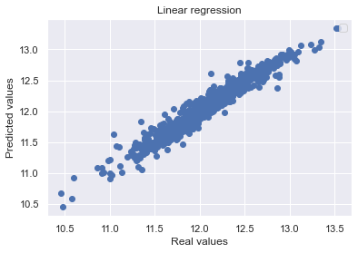

```
No handles with labels found to put in legend.
```

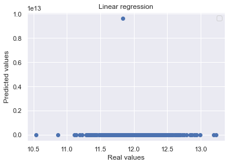

```python
scatter_plot(y_train, y_train_11)
scatter_plot(y_test, y_pred)
```

**5. Tabulate result**

```python
# Generate report
report.loc[report.shape[0]] = ['linear_reg', train_rmse, test_rmse]
report
```

|  | Model | train_rmse | test_rmse |
| --- | --- | --- | --- |
| 0 | linear_reg | 0.096802 | 5.643856e+11 |

## 7.2 Ridge Regression

**Go to table of contents**

```python
from sklearn.linear_model import RidgeCV
```

**1. Build the model**

```python
# Train the model
ridge_reg = RidgeCV(alphas = [1e-3, 1e-2, 1e-1, 1])
ridge_reg.fit(X_train, y_train)
```

```
RidgeCV(alphas=array([0.001, 0.01 , 0.1  , 1.   ]))
```

**2. Make predictions**

```python
# Test model
y_train_12 = ridge_reg.predict(X_train)
y_pred = ridge_reg.predict(X_test)
```

**3. Computer metrics**

```python
# Get rmse score
train_rmse = error(y_train, y_train_12)
print("Train RMSE Score : ", train_rmse)
test_rmse = error(y_test, y_pred)
print("Test RMSE Score : ", test_rmse)
```

```
Train RMSE Score :  0.10070890135598072
Test RMSE Score :  0.14664392445445107
```

**4. Plot RMSE**

```
No handles with labels found to put in legend.
```

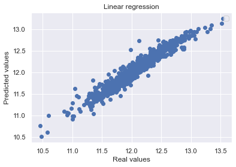

```
No handles with labels found to put in legend.
```

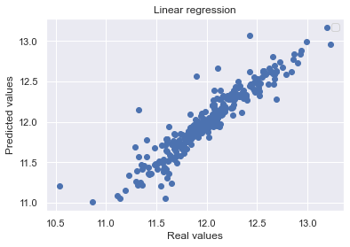

```python
scatter_plot(y_train, y_train_12)
scatter_plot(y_test, y_pred)
```

**5. Tabulate Result**

```python
# Generate report
report.loc[report.shape[0]] = ['ridge_reg', train_rmse, test_rmse]
report
```

|  | Model | train_rmse | test_rmse |
| --- | --- | --- | --- |
| 0 | linear_reg | 0.096802 | 5.643856e+11 |
| 1 | ridge_reg | 0.100709 | 1.466439e-01 |

## 7.3 Lasso Regression

**Go to table of contents**

```python
from sklearn.linear_model import LassoCV
```

**1. Get best alpha**

```python
lasso_reg = LassoCV(alphas = [0.0001, 0.0003, 0.0006, 0.001, 0.003, 0.006, 0.01, 0.03, 0.06, 0.1,
                          0.3, 0.6, 1],
                max_iter = 50000, cv = 10)
lasso_reg.fit(X_train, y_train)
alpha = lasso_reg.alpha_
print("Best alpha :", alpha)
```

```
Best alpha : 0.0006
```

**2. Build model using best alpha**

```python
# Chossing alphas centered around 0.0003
lasso_reg = LassoCV(alphas = [alpha * .3, alpha * .35, alpha * .7, alpha * .75, alpha * .8,
                          alpha * .85, alpha * .9, alpha * .95, alpha, alpha * 1.05,
                          alpha * 1.1, alpha * 1.15, alpha * 1.25, alpha * 1.3, alpha * 1.35,
                          alpha * 1.4],
                max_iter = 50000, cv = 10)
lasso_reg.fit(X_train, y_train)
alpha = lasso_reg.alpha_
print("Best alpha :", alpha)
```

```
Best alpha : 0.00041999999999999996
```

**3. Make predictions**

```python
# Test model
y_train_13 = lasso_reg.predict(X_train)
y_pred = lasso_reg.predict(X_test)
```

**4. Calculate metrics**

```python
# Get rmse score
train_rmse = error(y_train, y_train_13)
print("Train RMSE Score : ", train_rmse)
test_rmse = error(y_test, y_pred)
print("Test RMSE Score : ", test_rmse)
```

```
Train RMSE Score :  0.1063444694788242
Test RMSE Score :  0.13370437528483645
```

**5. Plot RMSE score**

```
No handles with labels found to put in legend.
```

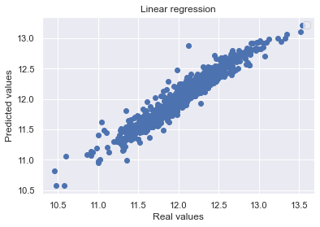

```
No handles with labels found to put in legend.
```

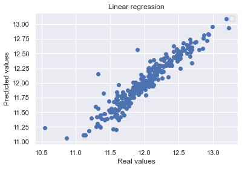

```python
scatter_plot(y_train, y_train_13)
scatter_plot(y_test, y_pred)
```

**6. Plot important coeffients considerd by lasso regressor**

```
Lasso picked 116 features and eliminated the other 122 features
```

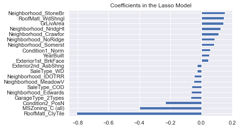

```python
# Plot important coefficients
coefs = pd.Series(lasso_reg.coef_, index = train.columns)
print("Lasso picked " + str(sum(coefs != 0)) + " features and eliminated the other " +  str(sum(coefs == 0)) + " features")

imp_coefs = pd.concat([coefs.sort_values().head(10),
                     coefs.sort_values().tail(10)])
imp_coefs.plot(kind = "barh")
plt.title("Coefficients in the Lasso Model")
plt.show()
```

**7. Tabulate result**

```python
# Generate report
report.loc[report.shape[0]] = ['lasso_reg', train_rmse, test_rmse]
report
```

|  | Model | train_rmse | test_rmse |
| --- | --- | --- | --- |
| 0 | linear_reg | 0.096802 | 5.643856e+11 |
| 1 | ridge_reg | 0.100709 | 1.466439e-01 |
| 2 | lasso_reg | 0.106344 | 1.337044e-01 |

## 7.4 ElasticNet Regression

**Go to table of contents**

```python
from sklearn.linear_model import ElasticNetCV
```

**1. Build the model**

```python
# Train the model
elasticnet_reg = ElasticNetCV(l1_ratio = [0.1, 0.3, 0.5, 0.6, 0.7, 0.8, 0.85, 0.9, 0.95, 1],
                          alphas = [0.0001, 0.0003, 0.0006, 0.001, 0.003, 0.006,
                                    0.01, 0.03, 0.06, 0.1, 0.3, 0.6, 1, 3, 6],
                          max_iter = 50000, cv = 10)
elasticnet_reg.fit(X_train, y_train)
```

```
ElasticNetCV(alphas=[0.0001, 0.0003, 0.0006, 0.001, 0.003, 0.006, 0.01, 0.03,
                     0.06, 0.1, 0.3, 0.6, 1, 3, 6],
             cv=10, l1_ratio=[0.1, 0.3, 0.5, 0.6, 0.7, 0.8, 0.85, 0.9, 0.95, 1],
             max_iter=50000)
```

**2. Make predictions**

```python
# Test model
y_train_14 = elasticnet_reg.predict(X_train)
y_pred = elasticnet_reg.predict(X_test)
```

**3. Compute metrics**

```python
# Get rmse score
train_rmse = error(y_train, y_train_14)
print("Train RMSE Score : ", train_rmse)
test_rmse = error(y_test, y_pred)
print("Test RMSE Score : ", test_rmse)
```

```
Train RMSE Score :  0.10736602086878769
Test RMSE Score :  0.1338622694729022
```

**4. Plot RMSE Score**

```
No handles with labels found to put in legend.
```

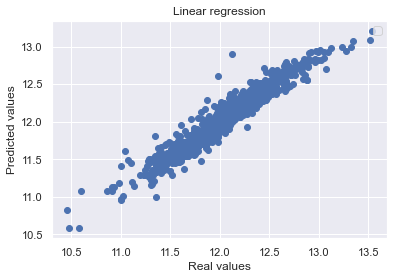

```
No handles with labels found to put in legend.
```

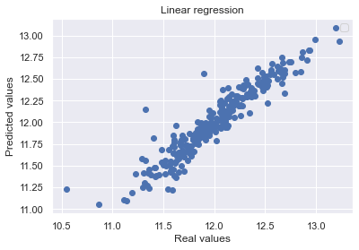

```python
scatter_plot(y_train, y_train_14)
scatter_plot(y_test, y_pred)
```

**5. Plot features picked by elastic net regressor**

```
ElasticNet picked 115 features and eliminated the other 123 features
```

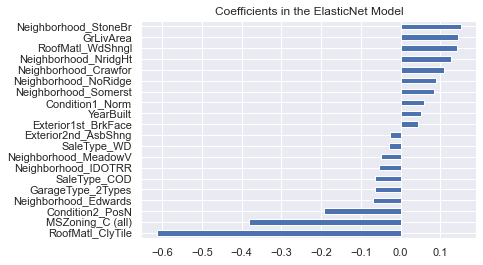

```python
# Plot important coefficients
coefs = pd.Series(elasticnet_reg.coef_, index = train.columns)
print("ElasticNet picked " + str(sum(coefs != 0)) + " features and eliminated the other " +  str(sum(coefs == 0)) + " features")

imp_coefs = pd.concat([coefs.sort_values().head(10),
                     coefs.sort_values().tail(10)])
imp_coefs.plot(kind = "barh")
plt.title("Coefficients in the ElasticNet Model")
plt.show()
```

**6. Tabulate Result**

```python
# Generate report
report.loc[report.shape[0]] = ['elasticnet_reg', train_rmse, test_rmse]
report
```

|  | Model | train_rmse | test_rmse |
| --- | --- | --- | --- |
| 0 | linear_reg | 0.096802 | 5.643856e+11 |
| 1 | ridge_reg | 0.100709 | 1.466439e-01 |
| 2 | lasso_reg | 0.106344 | 1.337044e-01 |
| 3 | elasticnet_reg | 0.107366 | 1.338623e-01 |

## 7.5 XGBRegressor

**Go to table of contents**

```python
import xgboost as xgb
from xgboost.sklearn import XGBRegressor
from sklearn.model_selection import GridSearchCV
```

**1. Hyperparameter Tuning**

**GridSearchCV params:**

**Hyper Parameters :**

- **learning rate** - Learning rate for training model
- **early_stopping_rounds** - The number of rounds without improvements after which we should stop
- **max_depth** - It is the maximum number of nodes allowed from the root to the farthest leaf of a tree
- **min_child_weight** - It is the minimum weight required in order to create a new node in the tree.
- **subsample** - Subsample ratio of the training instances. Setting it to 0.5 means that XGBoost would randomly sample half of the training data prior to growing trees. and this will prevent overfitting.
- **colsample_bytree** - specify the fraction of columns to be subsampled.

```python
def hyperParameterTuning(X_train, y_train):
    param_tuning = {
        'learning_rate': [0.01, 0.1],
        'max_depth': [3, 5, 7, 10],
        'min_child_weight': [1, 3, 5],
        'subsample': [0.5, 0.7],
        'colsample_bytree': [0.5, 0.7],
        'n_estimators' : [100, 200, 500],
        'objective': ['reg:squarederror']
    }

    xgb_model = XGBRegressor()

    gsearch = GridSearchCV(estimator = xgb_model,
                           param_grid = param_tuning,
                           cv = 3,
                           n_jobs = -1,
                           verbose = 1)

    gsearch.fit(X_train,y_train)

    return gsearch.best_params_
```

```python
best_params = hyperParameterTuning(X_train, y_train)
best_params
```

```
Fitting 3 folds for each of 288 candidates, totalling 864 fits
```

```
[Parallel(n_jobs=-1)]: Using backend LokyBackend with 4 concurrent workers.
[Parallel(n_jobs=-1)]: Done  42 tasks      | elapsed:   10.1s
[Parallel(n_jobs=-1)]: Done 192 tasks      | elapsed:   49.7s
[Parallel(n_jobs=-1)]: Done 442 tasks      | elapsed:  2.6min
[Parallel(n_jobs=-1)]: Done 792 tasks      | elapsed:  4.9min
[Parallel(n_jobs=-1)]: Done 864 out of 864 | elapsed:  5.9min finished
```

```
{'colsample_bytree': 0.7,
 'learning_rate': 0.1,
 'max_depth': 3,
 'min_child_weight': 1,
 'n_estimators': 500,
 'objective': 'reg:squarederror',
 'subsample': 0.5}
```

**2. Build the model**

```python
# Train the model
xgb_model = XGBRegressor(objective = 'reg:squarederror',
        colsample_bytree = 0.7,
        learning_rate = 0.1,
        max_depth = 3,
        min_child_weight = 1,
        n_estimators = 500,
        subsample = 0.5)

xgb_model.fit(X_train, y_train)
```

```
XGBRegressor(base_score=0.5, booster='gbtree', colsample_bylevel=1,
             colsample_bynode=1, colsample_bytree=0.7, gamma=0, gpu_id=-1,
             importance_type='gain', interaction_constraints='',
             learning_rate=0.1, max_delta_step=0, max_depth=3,
             min_child_weight=1, missing=nan, monotone_constraints='()',
             n_estimators=500, n_jobs=0, num_parallel_tree=1, random_state=0,
             reg_alpha=0, reg_lambda=1, scale_pos_weight=1, subsample=0.5,
             tree_method='exact', validate_parameters=1, verbosity=None)
```

**3. Make predictions**

```python
# Test model
y_train_14 = xgb_model.predict(X_train)
y_pred = xgb_model.predict(X_test)
```

**4. Compute metrics**

```python
# Get rmse score
train_rmse = error(y_train, y_train_14)
print("Train RMSE Score : ", train_rmse)
test_rmse = error(y_test, y_pred)
print("Test RMSE Score : ", test_rmse)
```

```
Train RMSE Score :  0.04117932453735137
Test RMSE Score :  0.1414543373302158
```

**5. Plot RMSE Score**

```
No handles with labels found to put in legend.
```

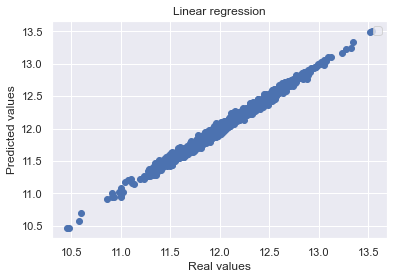

```
No handles with labels found to put in legend.
```

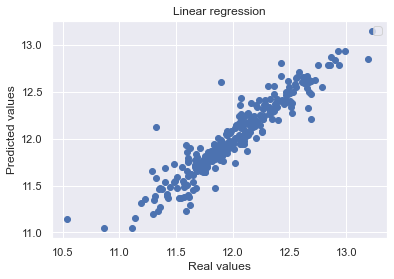

```python
scatter_plot(y_train, y_train_14)
scatter_plot(y_test, y_pred)
```

**6. Tabulate Result**

```python
# Generate report
report.loc[report.shape[0]] = ['xgb_reg', train_rmse, test_rmse]
report
```

|  | Model | train_rmse | test_rmse |
| --- | --- | --- | --- |
| 0 | linear_reg | 0.096802 | 5.643856e+11 |
| 1 | ridge_reg | 0.100709 | 1.466439e-01 |
| 2 | lasso_reg | 0.106344 | 1.337044e-01 |
| 3 | elasticnet_reg | 0.107366 | 1.338623e-01 |
| 4 | xgb_reg | 0.041179 | 1.414543e-01 |

## 8. Model Comparision

**Go to table of contents**

```python
report
```

|  | Model | train_rmse | test_rmse |
| --- | --- | --- | --- |
| 0 | linear_reg | 0.096802 | 5.643856e+11 |
| 1 | ridge_reg | 0.100709 | 1.466439e-01 |
| 2 | lasso_reg | 0.106344 | 1.337044e-01 |
| 3 | elasticnet_reg | 0.107366 | 1.338623e-01 |
| 4 | xgb_reg | 0.041179 | 1.414543e-01 |

```python
best_model = xgb_model
```

## 9. Kaggle Submission

**Go to table of contents**

```python
# Reading test file from kaggle
test = pd.read_csv("../input/house-prices-advanced-regression-techniques/test.csv")
test.head()
```

|  | Id | MSSubClass | MSZoning | LotFrontage | LotArea | Street | Alley | LotShape | LandContour | Utilities | ... | ScreenPorch | PoolArea | PoolQC | Fence | MiscFeature | MiscVal | MoSold | YrSold | SaleType | SaleCondition |
| --- | --- | --- | --- | --- | --- | --- | --- | --- | --- | --- | --- | --- | --- | --- | --- | --- | --- | --- | --- | --- | --- |
| 0 | 1461 | 20 | RH | 80.0 | 11622 | Pave | NaN | Reg | Lvl | AllPub | ... | 120 | 0 | NaN | MnPrv | NaN | 0 | 6 | 2010 | WD | Normal |
| 1 | 1462 | 20 | RL | 81.0 | 14267 | Pave | NaN | IR1 | Lvl | AllPub | ... | 0 | 0 | NaN | NaN | Gar2 | 12500 | 6 | 2010 | WD | Normal |
| 2 | 1463 | 60 | RL | 74.0 | 13830 | Pave | NaN | IR1 | Lvl | AllPub | ... | 0 | 0 | NaN | MnPrv | NaN | 0 | 3 | 2010 | WD | Normal |
| 3 | 1464 | 60 | RL | 78.0 | 9978 | Pave | NaN | IR1 | Lvl | AllPub | ... | 0 | 0 | NaN | NaN | NaN | 0 | 6 | 2010 | WD | Normal |
| 4 | 1465 | 120 | RL | 43.0 | 5005 | Pave | NaN | IR1 | HLS | AllPub | ... | 144 | 0 | NaN | NaN | NaN | 0 | 1 | 2010 | WD | Normal |

5 rows × 80 columns

```python
# get the count of missing values
missing_test = test.isnull().sum()

# get features with missing values greater than 0
missing_test = missing_test[missing_test > 0]

missing_test.sort_values(inplace = True, ascending = False)
_missingtest = pd.DataFrame()
_missingtest["Features"] = missing_test.index
_missingtest["Count"] = missing_test.values
_missingtest["Percentage"] = missing_test.values / test.shape[0] * 100
_missingtest["Type"] = [test[i].dtype for i in missing_test.index]
_missingtest
```

|  | Features | Count | Percentage | Type |
| --- | --- | --- | --- | --- |
| 0 | PoolQC | 1456 | 99.794380 | object |
| 1 | MiscFeature | 1408 | 96.504455 | object |
| 2 | Alley | 1352 | 92.666210 | object |
| 3 | Fence | 1169 | 80.123372 | object |
| 4 | FireplaceQu | 730 | 50.034270 | object |
| 5 | LotFrontage | 227 | 15.558602 | float64 |
| 6 | GarageYrBlt | 78 | 5.346127 | float64 |
| 7 | GarageCond | 78 | 5.346127 | object |
| 8 | GarageQual | 78 | 5.346127 | object |
| 9 | GarageFinish | 78 | 5.346127 | object |
| 10 | GarageType | 76 | 5.209047 | object |
| 11 | BsmtCond | 45 | 3.084304 | object |
| 12 | BsmtExposure | 44 | 3.015764 | object |
| 13 | BsmtQual | 44 | 3.015764 | object |
| 14 | BsmtFinType1 | 42 | 2.878684 | object |
| 15 | BsmtFinType2 | 42 | 2.878684 | object |
| 16 | MasVnrType | 16 | 1.096642 | object |
| 17 | MasVnrArea | 15 | 1.028101 | float64 |
| 18 | MSZoning | 4 | 0.274160 | object |
| 19 | BsmtFullBath | 2 | 0.137080 | float64 |
| 20 | BsmtHalfBath | 2 | 0.137080 | float64 |
| 21 | Utilities | 2 | 0.137080 | object |
| 22 | Functional | 2 | 0.137080 | object |
| 23 | Exterior2nd | 1 | 0.068540 | object |
| 24 | Exterior1st | 1 | 0.068540 | object |
| 25 | SaleType | 1 | 0.068540 | object |
| 26 | BsmtFinSF1 | 1 | 0.068540 | float64 |
| 27 | BsmtFinSF2 | 1 | 0.068540 | float64 |
| 28 | BsmtUnfSF | 1 | 0.068540 | float64 |
| 29 | KitchenQual | 1 | 0.068540 | object |
| 30 | GarageCars | 1 | 0.068540 | float64 |
| 31 | GarageArea | 1 | 0.068540 | float64 |
| 32 | TotalBsmtSF | 1 | 0.068540 | float64 |

```python
cleaned_test = test.copy(deep = True)
```

```python
# Handling Missing values - similar to that of training data
cleaned_test['PoolQC'] = cleaned_test.loc[:, "PoolQC"].fillna("No")
cleaned_test['MiscFeature'] = cleaned_test.loc[:, "MiscFeature"].fillna("None")
cleaned_test['Alley'] = cleaned_test.loc[:, "Alley"].fillna("None")
cleaned_test['Fence'] = cleaned_test.loc[:, "Fence"].fillna("No")
cleaned_test['FireplaceQu'] = cleaned_test.loc[:, "FireplaceQu"].fillna("No")
cleaned_test['LotFrontage'] = cleaned_test.loc[:, "LotFrontage"].fillna(0)
cleaned_test['GarageCond'] = cleaned_test.loc[:, "GarageCond"].fillna("No")
cleaned_test['GarageQual'] = cleaned_test.loc[:, "GarageQual"].fillna("No")
cleaned_test['GarageFinish'] = cleaned_test.loc[:, "GarageFinish"].fillna("No")
cleaned_test['GarageType'] = cleaned_test.loc[:, "GarageType"].fillna("No")
cleaned_test['BsmtCond'] = cleaned_test.loc[:, "BsmtCond"].fillna("No")
cleaned_test['BsmtExposure'] = cleaned_test.loc[:, "BsmtExposure"].fillna("None")
cleaned_test['BsmtQual'] = cleaned_test.loc[:, "BsmtQual"].fillna("No")
cleaned_test['BsmtFinType1'] = cleaned_test.loc[:, "BsmtFinType1"].fillna("No")
cleaned_test['BsmtFinType2'] = cleaned_test.loc[:, "BsmtFinType2"].fillna("No")
cleaned_test['MasVnrType'] = cleaned_test.loc[:, "MasVnrType"].fillna("None")
cleaned_test['MasVnrArea'] = cleaned_test.loc[:, "MasVnrArea"].fillna(0)
cleaned_test['BsmtFullBath'] = cleaned_test.loc[:, "BsmtFullBath"].fillna(0)
cleaned_test['BsmtHalfBath'] = cleaned_test.loc[:, "BsmtHalfBath"].fillna(0)
cleaned_test['Functional'] = cleaned_test.loc[:, "Functional"].fillna("None")
cleaned_test['Utilities'] = cleaned_test.loc[:, "Utilities"].fillna("NoSeWa")
cleaned_test['GarageCars'] = cleaned_test.loc[:, "GarageCars"].fillna(0)
cleaned_test['GarageArea'] = cleaned_test.loc[:, "GarageArea"].fillna(0)
cleaned_test['TotalBsmtSF'] = cleaned_test.loc[:, "TotalBsmtSF"].fillna(0)
cleaned_test['KitchenQual'] = cleaned_test.loc[:, "KitchenQual"].fillna("Po")
cleaned_test['BsmtUnfSF'] = cleaned_test.loc[:, "BsmtUnfSF"].fillna(0)
cleaned_test['BsmtFinSF2'] = cleaned_test.loc[:, "BsmtFinSF2"].fillna(0)
cleaned_test['BsmtFinSF1'] = cleaned_test.loc[:, "BsmtFinSF1"].fillna(0)
cleaned_test['Exterior2nd'] = cleaned_test.loc[:, "Exterior2nd"].fillna("Other")
cleaned_test['Exterior1st'] = cleaned_test.loc[:, "Exterior1st"].fillna("Stone")
cleaned_test['SaleType'] = cleaned_test.loc[:, "SaleType"].fillna("Oth")
```

```python
# Converting object features to categorical
cleaned_test = convert_type(cleaned_test, [i for i in cleaned_test.columns.values if cleaned_test[i].dtype == "object"])
```

```python
# Converting categorical features to numeric
cleaned_test["MSSubClass"] = cleaned_test.MSSubClass.map(mssubclass)
cleaned_test["MoSold"] = cleaned_test.MoSold.map(msold)
cleaned_test = convert_type(cleaned_test, ["MSSubClass", "MoSold"])


cleaned_test = cleaned_test.replace({"Alley" : {"None": 0, "Grvl" : 1, "Pave" : 2},
                       "CentralAir" : {"N" : 0, "Y" : 1},
                       "BsmtCond" : {"No" : 0, "Po" : 1, "Fa" : 2, "TA" : 3, "Gd" : 4, "Ex" : 5},
                       "BsmtExposure" : {"No" : 0, "None": 0, "Mn" : 1, "Av": 2, "Gd" : 3},
                       "BsmtFinType1" : {"No" : 0, "Unf" : 1, "LwQ": 2, "Rec" : 3, "BLQ" : 4,
                                         "ALQ" : 5, "GLQ" : 6},
                       "BsmtFinType2" : {"No" : 0, "Unf" : 1, "LwQ": 2, "Rec" : 3, "BLQ" : 4,
                                         "ALQ" : 5, "GLQ" : 6},
                       "BsmtQual" : {"No" : 0, "Po" : 1, "Fa" : 2, "TA": 3, "Gd" : 4, "Ex" : 5},
                       "ExterCond" : {"Po" : 1, "Fa" : 2, "TA": 3, "Gd": 4, "Ex" : 5},
                       "ExterQual" : {"Po" : 1, "Fa" : 2, "TA": 3, "Gd": 4, "Ex" : 5},
                       "FireplaceQu" : {"No" : 0, "Po" : 1, "Fa" : 2, "TA" : 3, "Gd" : 4, "Ex" : 5},
                       "Functional" : {"None" : 0, "Sal" : 1, "Sev" : 2, "Maj2" : 3, "Maj1" : 4, "Mod": 5,
                                       "Min2" : 6, "Min1" : 7, "Typ" : 8},
                       "GarageCond" : {"No" : 0, "Po" : 1, "Fa" : 2, "TA" : 3, "Gd" : 4, "Ex" : 5},
                       "GarageQual" : {"No" : 0, "Po" : 1, "Fa" : 2, "TA" : 3, "Gd" : 4, "Ex" : 5},
                       "GarageFinish" : {'Fin' : 3, 'RFn' : 2, 'Unf' : 1, 'No' : 0},
                       "HeatingQC" : {"Po" : 1, "Fa" : 2, "TA" : 3, "Gd" : 4, "Ex" : 5},
                       "KitchenQual" : {"Po" : 1, "Fa" : 2, "TA" : 3, "Gd" : 4, "Ex" : 5},
                       "LandSlope" : {"Sev" : 1, "Mod" : 2, "Gtl" : 3},
                       "LotShape" : {"IR3" : 1, "IR2" : 2, "IR1" : 3, "Reg" : 4},
                       "PavedDrive" : {"N" : 0, "P" : 1, "Y" : 2},
                       "PoolQC" : {"No" : 0, "Fa" : 1, "TA" : 2, "Gd" : 3, "Ex" : 4},
                       "Street" : {"Grvl" : 1, "Pave" : 2},
                       "Fence" : {'GdPrv' : 4, 'GdWo' : 2, 'MnPrv' : 3, 'MnWw' : 1, 'No' : 0},
                       "SaleCondition" : {"Abnorml" : 0, "Alloca" : 0, "AdjLand" : 0, "Family" : 0, "Normal" : 0, "Partial" : 1},
                       "MasVnrType" : {'BrkCmn' : 1, 'BrkFace' : 1, 'None' : 0, 'Stone' : 1, "CBlock" : 1},
                       "Utilities" : {"ELO" : 1, "NoSeWa" : 2, "NoSewr" : 3, "AllPub" : 4}}
                     )

# Simplying numeric features

cleaned_test["OverallQual"] = cleaned_test.OverallQual.replace({1 : 1, 2 : 1, 3 : 1, # bad
                                                       4 : 2, 5 : 2, 6 : 2, # average
                                                       7 : 3, 8 : 3, 9 : 3, 10 : 3 # good
                                                      })
cleaned_test["OverallCond"] = cleaned_test.OverallCond.replace({1 : 1, 2 : 1, 3 : 1, # bad
                                                       4 : 2, 5 : 2, 6 : 2, # average
                                                       7 : 3, 8 : 3, 9 : 3, 10 : 3 # good
                                                      })
cleaned_test["PoolQC"] = cleaned_test.PoolQC.replace({1 : 1, 2 : 1, # average
                                             3 : 2, 4 : 2 # good
                                            })
cleaned_test["GarageCond"] = cleaned_test.GarageCond.replace({1 : 1, # bad
                                                     2 : 1, 3 : 1, # average
                                                     4 : 2, 5 : 2 # good
                                                    })
cleaned_test["GarageQual"] = cleaned_test.GarageQual.replace({1 : 1, # bad
                                                     2 : 1, 3 : 1, # average
                                                     4 : 2, 5 : 2 # good
                                                    })
cleaned_test["FireplaceQu"] = cleaned_test.FireplaceQu.replace({1 : 1, # bad
                                                       2 : 1, 3 : 1, # average
                                                       4 : 2, 5 : 2 # good
                                                      })
cleaned_test["Functional"] = cleaned_test.Functional.replace({1 : 1, 2 : 1, # bad
                                                     3 : 2, 4 : 2, # major
                                                     5 : 3, 6 : 3, 7 : 3, # minor
                                                     8 : 4 # typical
                                                    })
cleaned_test["KitchenQual"] = cleaned_test.KitchenQual.replace({1 : 0, # bad
                                                       2 : 1, 3 : 1, # average
                                                       4 : 2, 5 : 2 # good
                                                      })
cleaned_test["HeatingQC"] = cleaned_test.HeatingQC.replace({1 : 0, # bad
                                                   2 : 1, 3 : 1, # average
                                                   4 : 2, 5 : 2 # good
                                                  })
cleaned_test["BsmtFinType1"] = cleaned_test.BsmtFinType1.replace({1 : 1, # unfinished
                                                         2 : 1, 3 : 1, # rec room
                                                         4 : 2, 5 : 2, 6 : 2 # living quarters
                                                        })
cleaned_test["BsmtFinType2"] = cleaned_test.BsmtFinType2.replace({1 : 1, # unfinished
                                                         2 : 1, 3 : 1, # rec room
                                                         4 : 2, 5 : 2, 6 : 2 # living quarters
                                                        })
cleaned_test["BsmtCond"] = cleaned_test.BsmtCond.replace({1 : 1, # bad
                                                 2 : 1, 3 : 1, # average
                                                 4 : 2, 5 : 2 # good
                                                })
cleaned_test["BsmtQual"] = cleaned_test.BsmtQual.replace({1 : 1, # bad
                                                 2 : 1, 3 : 1, # average
                                                 4 : 2, 5 : 2 # good
                                                })
cleaned_test["ExterCond"] = cleaned_test.ExterCond.replace({1 : 0, # bad
                                                   2 : 1, 3 : 1, # average
                                                   4 : 2, 5 : 2 # good
                                                  })
cleaned_test["ExterQual"] = cleaned_test.ExterQual.replace({1 : 0, # bad
                                                   2 : 1, 3 : 1, # average
                                                   4 : 2, 5 : 2 # good
                                                  })

cleaned_test.info()
```

```
<class 'pandas.core.frame.DataFrame'>
RangeIndex: 1459 entries, 0 to 1458
Data columns (total 80 columns):
 #   Column         Non-Null Count  Dtype
---  ------         --------------  -----
 0   Id             1459 non-null   int64
 1   MSSubClass     1459 non-null   category
 2   MSZoning       1455 non-null   category
 3   LotFrontage    1459 non-null   float64
 4   LotArea        1459 non-null   int64
 5   Street         1459 non-null   int64
 6   Alley          1459 non-null   int64
 7   LotShape       1459 non-null   int64
 8   LandContour    1459 non-null   category
 9   Utilities      1459 non-null   int64
```

[output cut: 72 more lines]

```python
# Dropping GarageYrBlt as it is dropped while training
cleaned_test.drop("GarageYrBlt", inplace = True, axis = 1)
```

```python
# Get dataframe of only numerical features
numeric_test = cleaned_test[cleaned_test.select_dtypes(include = ["int64", "float64"]).columns]

# Get dataframe of only categorical features
cat_test = cleaned_test[cleaned_test.select_dtypes(exclude = ["int64", "float64"]).columns]
```

```python
# Reducing Skewness of features
numeric_test = numeric_test.copy()
numeric_test.loc[:,skewed_features] = np.log1p(numeric_test[skewed_features])
```

```python
# Creating dummies variables
cat_test = pd.get_dummies(cat_test)
cat_test
```

|  | MSSubClass_SC120 | MSSubClass_SC150 | MSSubClass_SC160 | MSSubClass_SC180 | MSSubClass_SC190 | MSSubClass_SC20 | MSSubClass_SC30 | MSSubClass_SC40 | MSSubClass_SC45 | MSSubClass_SC50 | ... | MoSold_Sep | SaleType_COD | SaleType_CWD | SaleType_Con | SaleType_ConLD | SaleType_ConLI | SaleType_ConLw | SaleType_New | SaleType_Oth | SaleType_WD |
| --- | --- | --- | --- | --- | --- | --- | --- | --- | --- | --- | --- | --- | --- | --- | --- | --- | --- | --- | --- | --- | --- |
| 0 | 0 | 0 | 0 | 0 | 0 | 1 | 0 | 0 | 0 | 0 | ... | 0 | 0 | 0 | 0 | 0 | 0 | 0 | 0 | 0 | 1 |
| 1 | 0 | 0 | 0 | 0 | 0 | 1 | 0 | 0 | 0 | 0 | ... | 0 | 0 | 0 | 0 | 0 | 0 | 0 | 0 | 0 | 1 |
| 2 | 0 | 0 | 0 | 0 | 0 | 0 | 0 | 0 | 0 | 0 | ... | 0 | 0 | 0 | 0 | 0 | 0 | 0 | 0 | 0 | 1 |
| 3 | 0 | 0 | 0 | 0 | 0 | 0 | 0 | 0 | 0 | 0 | ... | 0 | 0 | 0 | 0 | 0 | 0 | 0 | 0 | 0 | 1 |
| 4 | 1 | 0 | 0 | 0 | 0 | 0 | 0 | 0 | 0 | 0 | ... | 0 | 0 | 0 | 0 | 0 | 0 | 0 | 0 | 0 | 1 |
| ... | ... | ... | ... | ... | ... | ... | ... | ... | ... | ... | ... | ... | ... | ... | ... | ... | ... | ... | ... | ... | ... |
| 1454 | 0 | 0 | 1 | 0 | 0 | 0 | 0 | 0 | 0 | 0 | ... | 0 | 0 | 0 | 0 | 0 | 0 | 0 | 0 | 0 | 1 |
| 1455 | 0 | 0 | 1 | 0 | 0 | 0 | 0 | 0 | 0 | 0 | ... | 0 | 0 | 0 | 0 | 0 | 0 | 0 | 0 | 0 | 1 |
| 1456 | 0 | 0 | 0 | 0 | 0 | 1 | 0 | 0 | 0 | 0 | ... | 1 | 0 | 0 | 0 | 0 | 0 | 0 | 0 | 0 | 1 |
| 1457 | 0 | 0 | 0 | 0 | 0 | 0 | 0 | 0 | 0 | 0 | ... | 0 | 0 | 0 | 0 | 0 | 0 | 0 | 0 | 0 | 1 |
| 1458 | 0 | 0 | 0 | 0 | 0 | 0 | 0 | 0 | 0 | 0 | ... | 0 | 0 | 0 | 0 | 0 | 0 | 0 | 0 | 0 | 1 |

1459 rows × 167 columns

```python
# Including dummy variables present in training set
def include_train_dummies(train, test):
    a = list(train.columns.values)
    b = list(test.columns.values)
    c = [i for i in a if i not in b]
    k = [0 for j in range(1459)]
    indexs = []
    for i in c:
        indexs.append(a.index(i))

    for i in range(len(c)):
        test.insert(indexs[i], c[i], k)

    return test

cat_test = include_train_dummies(cat_data, cat_test)
cat_test
```

|  | MSSubClass_SC120 | MSSubClass_SC150 | MSSubClass_SC160 | MSSubClass_SC180 | MSSubClass_SC190 | MSSubClass_SC20 | MSSubClass_SC30 | MSSubClass_SC40 | MSSubClass_SC45 | MSSubClass_SC50 | ... | MoSold_Sep | SaleType_COD | SaleType_CWD | SaleType_Con | SaleType_ConLD | SaleType_ConLI | SaleType_ConLw | SaleType_New | SaleType_Oth | SaleType_WD |
| --- | --- | --- | --- | --- | --- | --- | --- | --- | --- | --- | --- | --- | --- | --- | --- | --- | --- | --- | --- | --- | --- |
| 0 | 0 | 0 | 0 | 0 | 0 | 1 | 0 | 0 | 0 | 0 | ... | 0 | 0 | 0 | 0 | 0 | 0 | 0 | 0 | 0 | 1 |
| 1 | 0 | 0 | 0 | 0 | 0 | 1 | 0 | 0 | 0 | 0 | ... | 0 | 0 | 0 | 0 | 0 | 0 | 0 | 0 | 0 | 1 |
| 2 | 0 | 0 | 0 | 0 | 0 | 0 | 0 | 0 | 0 | 0 | ... | 0 | 0 | 0 | 0 | 0 | 0 | 0 | 0 | 0 | 1 |
| 3 | 0 | 0 | 0 | 0 | 0 | 0 | 0 | 0 | 0 | 0 | ... | 0 | 0 | 0 | 0 | 0 | 0 | 0 | 0 | 0 | 1 |
| 4 | 1 | 0 | 0 | 0 | 0 | 0 | 0 | 0 | 0 | 0 | ... | 0 | 0 | 0 | 0 | 0 | 0 | 0 | 0 | 0 | 1 |
| ... | ... | ... | ... | ... | ... | ... | ... | ... | ... | ... | ... | ... | ... | ... | ... | ... | ... | ... | ... | ... | ... |
| 1454 | 0 | 0 | 1 | 0 | 0 | 0 | 0 | 0 | 0 | 0 | ... | 0 | 0 | 0 | 0 | 0 | 0 | 0 | 0 | 0 | 1 |
| 1455 | 0 | 0 | 1 | 0 | 0 | 0 | 0 | 0 | 0 | 0 | ... | 0 | 0 | 0 | 0 | 0 | 0 | 0 | 0 | 0 | 1 |
| 1456 | 0 | 0 | 0 | 0 | 0 | 1 | 0 | 0 | 0 | 0 | ... | 1 | 0 | 0 | 0 | 0 | 0 | 0 | 0 | 0 | 1 |
| 1457 | 0 | 0 | 0 | 0 | 0 | 0 | 0 | 0 | 0 | 0 | ... | 0 | 0 | 0 | 0 | 0 | 0 | 0 | 0 | 0 | 1 |
| 1458 | 0 | 0 | 0 | 0 | 0 | 0 | 0 | 0 | 0 | 0 | ... | 0 | 0 | 0 | 0 | 0 | 0 | 0 | 0 | 0 | 1 |

1459 rows × 180 columns

```python
# Removing redundant features
Id = numeric_test['Id'].values.tolist()
numeric_test.drop('Id', inplace = True, axis = 1)
numeric_test
```

|  | LotFrontage | LotArea | Street | Alley | LotShape | Utilities | LandSlope | OverallQual | OverallCond | YearBuilt | ... | OpenPorchSF | EnclosedPorch | 3SsnPorch | ScreenPorch | PoolArea | PoolQC | Fence | MiscVal | YrSold | SaleCondition |
| --- | --- | --- | --- | --- | --- | --- | --- | --- | --- | --- | --- | --- | --- | --- | --- | --- | --- | --- | --- | --- | --- |
| 0 | 80.0 | 9.360741 | 1.098612 | 0.0 | 1.609438 | 1.609438 | 1.386294 | 2 | 1.098612 | 7.581720 | ... | 0.000000 | 0.0 | 0.0 | 4.795791 | 0.0 | 0.0 | 1.386294 | 0.000000 | 2010 | 0.0 |
| 1 | 81.0 | 9.565775 | 1.098612 | 0.0 | 1.386294 | 1.609438 | 1.386294 | 2 | 1.098612 | 7.580189 | ... | 3.610918 | 0.0 | 0.0 | 0.000000 | 0.0 | 0.0 | 0.000000 | 9.433564 | 2010 | 0.0 |
| 2 | 74.0 | 9.534668 | 1.098612 | 0.0 | 1.386294 | 1.609438 | 1.386294 | 2 | 1.098612 | 7.599902 | ... | 3.555348 | 0.0 | 0.0 | 0.000000 | 0.0 | 0.0 | 1.386294 | 0.000000 | 2010 | 0.0 |
| 3 | 78.0 | 9.208238 | 1.098612 | 0.0 | 1.386294 | 1.609438 | 1.386294 | 2 | 1.098612 | 7.600402 | ... | 3.610918 | 0.0 | 0.0 | 0.000000 | 0.0 | 0.0 | 0.000000 | 0.000000 | 2010 | 0.0 |
| 4 | 43.0 | 8.518392 | 1.098612 | 0.0 | 1.386294 | 1.609438 | 1.386294 | 3 | 1.098612 | 7.597396 | ... | 4.418841 | 0.0 | 0.0 | 4.976734 | 0.0 | 0.0 | 0.000000 | 0.000000 | 2010 | 0.0 |
| ... | ... | ... | ... | ... | ... | ... | ... | ... | ... | ... | ... | ... | ... | ... | ... | ... | ... | ... | ... | ... | ... |
| 1454 | 21.0 | 7.568896 | 1.098612 | 0.0 | 1.609438 | 1.609438 | 1.386294 | 2 | 1.386294 | 7.586296 | ... | 0.000000 | 0.0 | 0.0 | 0.000000 | 0.0 | 0.0 | 0.000000 | 0.000000 | 2006 | 0.0 |
| 1455 | 21.0 | 7.546974 | 1.098612 | 0.0 | 1.609438 | 1.609438 | 1.386294 | 2 | 1.098612 | 7.586296 | ... | 3.218876 | 0.0 | 0.0 | 0.000000 | 0.0 | 0.0 | 0.000000 | 0.000000 | 2006 | 0.0 |
| 1456 | 160.0 | 9.903538 | 1.098612 | 0.0 | 1.609438 | 1.609438 | 1.386294 | 2 | 1.386294 | 7.581210 | ... | 0.000000 | 0.0 | 0.0 | 0.000000 | 0.0 | 0.0 | 0.000000 | 0.000000 | 2006 | 0.0 |
| 1457 | 62.0 | 9.253591 | 1.098612 | 0.0 | 1.609438 | 1.609438 | 1.386294 | 2 | 1.098612 | 7.597396 | ... | 3.496508 | 0.0 | 0.0 | 0.000000 | 0.0 | 0.0 | 1.386294 | 6.552508 | 2006 | 0.0 |
| 1458 | 74.0 | 9.172431 | 1.098612 | 0.0 | 1.609438 | 1.609438 | 1.098612 | 3 | 1.098612 | 7.597898 | ... | 3.891820 | 0.0 | 0.0 | 0.000000 | 0.0 | 0.0 | 0.000000 | 0.000000 | 2006 | 0.0 |

1459 rows × 58 columns

```python
# List of numeric features
test_numeric_features = numeric_test.columns.values.tolist()
```

```python
# Standardizing test set
numeric_test = scaler.transform(numeric_test)
```

```python
# Converting numpy array object to dataframe
numeric_test = pd.DataFrame(numeric_test, columns = test_numeric_features)
numeric_test.head()
```

|  | LotFrontage | LotArea | Street | Alley | LotShape | Utilities | LandSlope | OverallQual | OverallCond | YearBuilt | ... | OpenPorchSF | EnclosedPorch | 3SsnPorch | ScreenPorch | PoolArea | PoolQC | Fence | MiscVal | YrSold | SaleCondition |
| --- | --- | --- | --- | --- | --- | --- | --- | --- | --- | --- | --- | --- | --- | --- | --- | --- | --- | --- | --- | --- | --- |
| 0 | 0.645874 | 0.482878 | 0.06426 | -0.250914 | 0.658804 | 0.026189 | 0.217756 | -0.697347 | -0.376061 | -0.330878 | ... | -1.073708 | -0.404405 | -0.128566 | 3.124990 | -0.069416 | -0.068252 | 2.083433 | -0.190549 | 1.644752 | -0.30611 |
| 1 | 0.674724 | 0.879181 | 0.06426 | -0.250914 | -0.894214 | 0.026189 | 0.217756 | -0.697347 | -0.376061 | -0.430357 | ... | 0.604588 | -0.404405 | -0.128566 | -0.292878 | -0.069416 | -0.068252 | -0.481286 | 7.503948 | 1.644752 | -0.30611 |
| 2 | 0.472773 | 0.819056 | 0.06426 | -0.250914 | -0.894214 | 0.026189 | 0.217756 | -0.697347 | -0.376061 | 0.851142 | ... | 0.578760 | -0.404405 | -0.128566 | -0.292878 | -0.069416 | -0.068252 | 2.083433 | -0.190549 | 1.644752 | -0.30611 |
| 3 | 0.588174 | 0.188110 | 0.06426 | -0.250914 | -0.894214 | 0.026189 | 0.217756 | -0.697347 | -0.376061 | 0.883671 | ... | 0.604588 | -0.404405 | -0.128566 | -0.292878 | -0.069416 | -0.068252 | -0.481286 | -0.190549 | 1.644752 | -0.30611 |
| 4 | -0.421579 | -1.145272 | 0.06426 | -0.250914 | -0.894214 | 0.026189 | 0.217756 | 1.248024 | -0.376061 | 0.688252 | ... | 0.980098 | -0.404405 | -0.128566 | 3.253945 | -0.069416 | -0.068252 | -0.481286 | -0.190549 | 1.644752 | -0.30611 |

5 rows × 58 columns

```python
# Concatenate numeric and categorical dataframes
final_test = pd.concat([numeric_test, cat_test], axis = 1)
final_test.head()
```

|  | LotFrontage | LotArea | Street | Alley | LotShape | Utilities | LandSlope | OverallQual | OverallCond | YearBuilt | ... | MoSold_Sep | SaleType_COD | SaleType_CWD | SaleType_Con | SaleType_ConLD | SaleType_ConLI | SaleType_ConLw | SaleType_New | SaleType_Oth | SaleType_WD |
| --- | --- | --- | --- | --- | --- | --- | --- | --- | --- | --- | --- | --- | --- | --- | --- | --- | --- | --- | --- | --- | --- |
| 0 | 0.645874 | 0.482878 | 0.06426 | -0.250914 | 0.658804 | 0.026189 | 0.217756 | -0.697347 | -0.376061 | -0.330878 | ... | 0 | 0 | 0 | 0 | 0 | 0 | 0 | 0 | 0 | 1 |
| 1 | 0.674724 | 0.879181 | 0.06426 | -0.250914 | -0.894214 | 0.026189 | 0.217756 | -0.697347 | -0.376061 | -0.430357 | ... | 0 | 0 | 0 | 0 | 0 | 0 | 0 | 0 | 0 | 1 |
| 2 | 0.472773 | 0.819056 | 0.06426 | -0.250914 | -0.894214 | 0.026189 | 0.217756 | -0.697347 | -0.376061 | 0.851142 | ... | 0 | 0 | 0 | 0 | 0 | 0 | 0 | 0 | 0 | 1 |
| 3 | 0.588174 | 0.188110 | 0.06426 | -0.250914 | -0.894214 | 0.026189 | 0.217756 | -0.697347 | -0.376061 | 0.883671 | ... | 0 | 0 | 0 | 0 | 0 | 0 | 0 | 0 | 0 | 1 |
| 4 | -0.421579 | -1.145272 | 0.06426 | -0.250914 | -0.894214 | 0.026189 | 0.217756 | 1.248024 | -0.376061 | 0.688252 | ... | 0 | 0 | 0 | 0 | 0 | 0 | 0 | 0 | 0 | 1 |

5 rows × 238 columns

```python
# Make predictions using best model
final_predictions = best_model.predict(final_test.values)
```

```python
# Creating a dataframe for submission
final_submission = pd.DataFrame()
final_submission["Id"] = Id
final_submission["SalePrice"] = final_predictions
final_submission
```

|  | Id | SalePrice |
| --- | --- | --- |
| 0 | 1461 | 11.689230 |
| 1 | 1462 | 12.014934 |
| 2 | 1463 | 12.210623 |
| 3 | 1464 | 12.149432 |
| 4 | 1465 | 12.204299 |
| ... | ... | ... |
| 1454 | 2915 | 11.311951 |
| 1455 | 2916 | 11.264343 |
| 1456 | 2917 | 12.004095 |
| 1457 | 2918 | 11.578978 |
| 1458 | 2919 | 12.314466 |

1459 rows × 2 columns

```python
# Saving submissions as a csv file
final_submission.to_csv("submission.csv", index=False)
```